# Heart rate in the voice

Supporting information

Marijn Hafkamp https://orcid.org/0000-0002-3719-7586 (Donders Institute for Brain, Cognition, and Behaviour)https://www.ru.nl/donders/ , Raphael Werner https://raphael-werner.github.io/ (Donders Institute for Brain, Cognition, and Behaviour)https://www.ru.nl/donders/ , Lara Burchardt https://www.leibniz-zas.de/de/personen/details/burchardt-lara-sophie/lara-sophie-burchardt (Donders Institute for Brain, Cognition, and Behaviour, ZAS Berlin)https://www.leibniz-zas.de/en/ , Luc Selen https://www.ru.nl/sensorimotorlab/people/current-members/luc-selen/ (Donders Institute for Brain, Cognition, and Behaviour)https://www.ru.nl/donders/ , Wim Pouw https://wimpouw.com/ (Donders Institute for Brain, Cognition, and Behaviour)https://www.ru.nl/donders/

**Show code setting up the packages**

```r
#R-packages
library(papaja)   #for Rmarkdown template for APA(ish) manuscript
library(distill) #for html output
library(ggplot2)    #for plotting
library(gridExtra)  #for plotting in panels
library(knitr)  #for document generation
library(magick)  #for plots
library(cowplot) #for plots
library(plyr) #for revalue
library(tinytex) #for outputting pdfs
library(readr)  #for data reading
library(bookdown) #for crossreferencing
library(rstudioapi) #for setting file paths
library(kableExtra) #for producing nicer tables
library(dplyr) #for data wrangling
library(ggbeeswarm) #for beeswarm plots
library(modelsummary) #for handling model summary tables
library(lme4) #for statistical modeling
library(lmerTest) #for statistical modeling
library(emmeans) #for post-hoc analysis
library(broom.mixed) #for turning fitted models into tidy data frames
library(viridis) #for viridis colorway
library(lmtest) #for Granger causality test

r_refs("references.bib")
```

This document contains further information on the supporting methods and results of Heart in Voice. For clarity, it is indicated on the right, what sections in the paper the respective part refers to. Code chunks are hidden by default, but can be made visible by clicking “Show code”.

# Supporting methods and results

This is a fully computationally reproducible manuscript written in R Markdown. The full dataset is available at the Donders Repository (redacted for review).

This refers to the section “Supporting information” of the paper.

**Show code loading and preparing the data**

```r
#Local data
localfolder <- "C:/Research_Projects/veni_local/exp100/" #"C:/Users/hafkamp.m/Documents/GitHub/VoiceAndHeart/large_data/exp100/"#"This points to your local data that you have downloaded from SURF"

#lets set all the data folders
rawd      <- paste0(localfolder, 'Trials/')    #raw trial level data
procd     <- paste0(localfolder, 'Processed/triallevel/') #processed data folder
procdtot  <- paste0(localfolder, 'Processed/complete_datasets/') #processed data folder
daset     <- paste0(localfolder, 'Dataset/')   #dataset folder
meta      <- paste0(localfolder, 'Meta/')   #Meta and trial data

#load in the trialinfo data (containing info like condition order, trial number etc)
trialf    <- list.files(meta, pattern = 'triallist*')
triallist <- data.frame()
for(i in trialf)
{
  tr        <- read.csv(paste0(meta, i), sep = ';')
  tr$ppn    <- parse_number(i)
  triallist <- rbind.data.frame(triallist,tr)
}

#make corrections to trial list due to experimenter errors
  # p10 trial 21 run with a weight
triallist$weight_condition[triallist$ppn==10 & triallist$trial=="21"] <- 'weight' #triallist$trialindex[triallist$ppn==10 & triallist$trial=="21"]
  # p14 double check trial "51", "52", "53" were all weight condition
triallist$weight_condition[triallist$ppn==14 & triallist$trial%in% c("51", "52", "53")] <- 'weight' #triallist$trialindex[triallist$ppn==14 & triallist$trial%in% c("51", "52", "53")]


#load in the metainfo data (containing info like gender, handedness, etc)
mtf     <- list.files(meta, pattern = 'bodymeta*')
mtlist  <- data.frame()
for(i in mtf)
{
  tr      <- read.csv(paste0(meta, i), sep = ';')
  mtlist  <- rbind.data.frame(mtlist,tr)
}
mtlist$ppn <- parse_number(as.character(mtlist$ppn))

# triallist combines all trial-related CSVs into a single dataframe.
# mtlist combines all metadata from multiple files into a single dataframe
# triallist and mtlist are now in memory and ready to be analyzed in later chunks.
```

# Supporting methods

This study has been approved by the Ethics Committee Social Sciences (ECSS) of the Radboud University (reference nr.: 22N.002642).

**Show code adding participant and condition information**

```r
# add some info about the dataset
participants  <- c(unique(mtlist$ppn)) # uses mtlist as created above
numpart       <- length(participants)

# number & percentage female & male participants
part_fem <- round(sum(mtlist$sex=='f'), 1)
perc_fem  <- round((sum(mtlist$sex=='f')/numpart)*100, 1)
part_male <- round(sum(mtlist$sex=='m'), 1)
perc_male <- round((sum(mtlist$sex=='m')/numpart)*100, 1)

# body info
m_age           <- round(mean(mtlist$age), 1)
sd_age          <- round(sd(mtlist$age), 1)
m_weight        <- round(mean(mtlist$weight), 1)
sd_weight       <- round(sd(mtlist$weight), 1)
m_height        <- round(mean(mtlist$height), 1)
sd_height       <- round(sd(mtlist$height), 1)
bmi             <- mtlist$weight/((mtlist$height/100)^2)
m_bmi           <- round(mean(bmi), 1)
sd_bmi          <- round(sd(bmi), 1)

# other body measurements
  # Function to calculate the mean of a character vector
  mean_of_char_vector <- function(vec) {
    mean(as.numeric(vec))}

skinfold  <- strsplit(mtlist$upperarmfold, '_')
# Applying the function to each element of the list and storing the results in a new vector
skinfs    <- sapply(skinfold, mean_of_char_vector)
m_skin    <- round(mean(skinfs), 1)
sd_skin   <- round(sd(skinfs), 1)
# we also measure upper/under arm length (but will leave it at this)

# read data
tr_wd <- read.csv(paste0(procdtot, 'fulldata.csv'))
tr_wd <- subset(tr_wd, trialindex > 8 & vocal_condition=='expire') #only real trials and only vocalization/expiration
numtrials = nrow(tr_wd)
perc_w = round((sum(tr_wd$weight_condition=='weight')/numtrials)*100, 1) #percentage weight
perc_pas = round((sum(tr_wd$movement_condition=='no movement')/numtrials)*100, 1) #percentage passive
perc_int = round((sum(tr_wd$movement_condition=='internal rotation')/numtrials)*100, 1) #percentage internal rotation
perc_ext = round((sum(tr_wd$movement_condition=='external rotation')/numtrials)*100, 1) #percentage external rotation
perc_flex = round((sum(tr_wd$movement_condition=='flexion')/numtrials)*100, 1) #percentage flexion
perc_extens = round((sum(tr_wd$movement_condition=='extension')/numtrials)*100, 1) #percentage extension
```

## Experimental design

This study concerned a two-level wrist-weight manipulation (no weight vs. weight), a two-level within-subject vocalization condition (expire vs. vocalize), and a five-level within-subject movement condition (‘no movement’, ‘extension’, ‘flexion’, ‘external rotation’, ‘internal rotation’). With 4 trial repetitions over the experiment, we yield 80 (2 weights x 2 vocalizations x 5 movements x 4 repetitions) trials per participant. Trials were blocked by weight condition and vocalization condition (so that weights and task did not switch from trial to trial). Within blocks all movement conditions were randomized.

## Participants

For the current pre-registered confirmatory experiment, as planned and supported by a power analysis (see [preregistration](https://osf.io/jhdq4)), we collected *N* = (17) participants: 7 female, 10 male, *M* (*SD*) age = 28.50 (6.50), M (*SD*) body weight = 72.10 kg (10.20), *M* (*SD*) body height = 175.10 cm (8.50), *M* (*SD*) BMI = 23.40 (2.20), *M* (*SD*) triceps skinfold = 19.10 mm (4.30).

## Measurements and equipment

### Body measurements

To enable future analyses of possible factors modulating individual-specific body properties, we collect some basic information about body properties. Namely, weight, under arm length, upper arm length, triceps skinfold, and upper arm circumference.

### Experiment protocol

The experiment was coded in Python using functions from PsychoPy. The experiment was controlled via a Brainvision Button Box (Brain Products GmbH, Munich, Germany), which was also streaming its output to the data collection PC unit.

### Wrist weights

To manipulate the mass set in motion, we apply a wrist weight. We use a TurnTuri sports wrist weight of 1 kg.

### Video and kinematics

The participants are recorded via a videocamera (Logitech StreamCam), sampling at 60 frames per second. We used Mediapipe (Lugaresi et al. 2019) to track the skeleton and facial movements, which is implemented in Masked-piper which we also use for masking the videos (Owoyele et al. 2022). The motion-tracked skeleton, specifically the wrist of the dominant hand, is used to estimate movement initiation, peak speed, and the end of the movement. The motion tracking is, however, only used for determining movement windows, and is not of central concern.

### Muscle activity (Surface ElectroMyography: sEMG)

We measured sEMG using a wired BrainAmp ExG system (Brain Products GmbH, Munich, Germany). Disposable surface electrodes (Kendall 24mm Arbo H124SG) were used, and for each of the four muscle targets we had 3 (active, reference, ground) electrodes (12 electrodes total). The sEMG system sampled at 2,500 Hz (for post-processing filters see below).  
For an overview of the electrode attachments, see Fig. S1. We prepare the skin surface for EMG application with a scrub gel (NuPrep) followed by cotton ball swipe with alcohol (Podior 70 %). Active and reference electrodes were attached with a 15mm distance center to center.

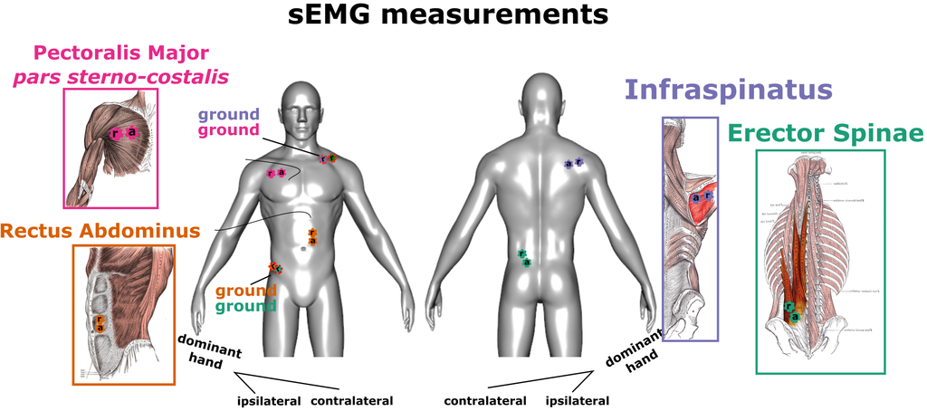

Figure 1: Overview sEMG target muscles. Active (a) and reference (r), and ground (g) sEMG electrodes, for each muscle target.

This refers to Figure S1 in the paper.

### Ground reaction measurements

We used an inhouse-built 1m² balance board with vertical pressure sensors. The sensors were derived and remodified from the Wii-Balance board sensors. The sampling rate was 400 Hz. The system was time-locked within millisecond accuracy, and has a spatial accuracy of several sub-millimeters. A national instruments card, USB-62221 performed the A/D conversion and was connected via USB to the PC.

### Acoustics

To ensure proper acoustic intensity measurements we used a headset microphone; MicroMic C520 (AKG, Inc.) headset condenser cardioid microphone sampling at 16 kHz. The gain levels of the condenser power source were set by the hardware (and could not be changed).

Here is one audio example from a male participant producing the sustained vocalization in the no movement condition without added weight.

**Show code setting up the audio examples**

```r
library(htmltools)

audioexamples <- paste0(basefolder, "/AudioExamples/")

audioexample_nomovement       <- paste0(audioexamples, "sample1_nomovement.wav")
# audioexample_internalrotation <- paste0(audioexamples, "sample2_internalrotation.wav")
# audioexample_flexion          <- paste0(audioexamples, "sample3_flexion.wav")
# audioexample_externalrotation <- paste0(audioexamples, "sample4_externalrotation.wav")
# audioexample_extension        <- paste0(audioexamples, "sample5_extension.wav")

html_tag_audio <- function(file, type = c("wav")) {
  type <- match.arg(type)
  htmltools::tags$audio(
    controls = NA,
    htmltools::tags$source(
      src = file,
      type = glue::glue("audio/{type}", type = type)
    )
  )
}
```

[interactive chart not shown]

### Recording setup and synchronization

We use [LabStreamLayer](https://github.com/sccn/labstreaminglayer) that provides a uniform interface for streaming different signals along a network, where a common time stamp for each signal ensures sub-millisecond synchronization. We used a Linux system to record and stream the microphone recordings. Additionally a second PC collected video, and streamed ground reaction forces, and EMG. A data collection PC collected the audio, ground reaction force, and EMG streams and stored the output in XDF format for efficient storing of multiple time-varying signals. The video data was synchronized by streaming the frame number to the LSL recorder, allowing us to match up individual frames with the other signals (even when a frame is dropped).

## Procedure

Participants are admitted to the study based on exclusion criteria and sign an informed consent. We ask participants to take off their shoes and we proceed with the body measurements, while instructing the participant about the nature of the study. After body measurements, we apply the surface EMG. We prepared the muscle site with rubbing gel and alcohol, and active/reference electrodes were placed with a distance of 15 mm from each other’s center. See Fig. S1 for the sEMG electrode locations. The procedures up to the start of the experiment take about 20 minutes or less in total.

Upon the start of the experiment participants take a standing position on the force platform. The experiment commences with calibration and practice trials. First, 10 seconds of silent breathing with body movements are recorded. Then participants are asked to take a maximum inspiration followed by a maximum expiration to measure signal conditions under respiratory boundary conditions. Then, for the practice trials, each movement was practiced with expiring and vocalization while performing the movement conditions, and the participant is introduced to wearing the wrist weight of 1 kg. After practice trials, participants performed 80 blocked trials.

For each (practice) trial participants are closely guided by the information on the monitor. Firstly, participants are shown the movement to be performed for the trial, and have to prompt the experimenter that they are ready to continue. Then participants are instructed to adopt the start position of the movement, which is a 90 degree elbow flexion, with either an externally rotated humerus (start position for internal rotation), or a non-rotated humerus with the wrist in front of the body (rest position for the other movement conditions). For the no movement condition participants are asked to rest their arms alongside their body. Upon trial start, participants are asked to inhale deeply with a timer counting down from 4 seconds. Then, participants are asked to ‘vocalize’ or ‘expire’, with a screen appearing after 3 seconds to perform the movement with visual guidance to where the movement end position is so that participants are reminded of the movement. After an additional 4 seconds the trial ends, which allows more than enough time to perform the movement and stabilize vocalization after the perturbation. In the no movement condition, a prompt is given to maintain one’s posture.

## Preprocessing of the data streams

### EMG

Rather than filtering the EMG signal to reduce heart rate artifacts (Drake and Callaghan 2006), we are particularly interested in the heart rate as present in the EMG signal. We thus remove any higher-frequency components from the signal and retain low-frequency bands, while removing the very low components to avoid baseline drift. This is done by high-pass filtering the signal at 0.75 Hz using a zero-phase 4th order Butterworth filter. We then full-wave rectified the EMG signal and applied a zero-phase low-pass 4th order Butterworth filter at 3 Hz. When filtering any signal we pad the signals to avoid edge effects. In other words, the pass-band from 0.75 to 3 Hz allows us to cover any heart rates from 45 to 180 beats per minute.

**Show code creating function for preprocessing EMG data**

```r
# load in the data and save it
library(signal)
library(ggrepel)

#####################preprocessing functions
butter.it <- function(x, samplingrate, order, cutoff, type = "low")
{
  nyquist <- samplingrate/2
  xpad <- c(rep(0, 1000), x, rep(0,1000)) #add some padding
  bf <- butter(order,cutoff/nyquist, type=type)
  xpad <- as.numeric(signal::filtfilt(bf, xpad))
  x <- xpad[1000:(1000+length(x)-1)] #remove the padding
}

#rectify and high and low pass EMG signals
reclow.it <- function(emgsignal, samplingrate, cutoffhigh, cutofflow)
  {
    #high pass filter
    output <- butter.it(emgsignal, samplingrate=samplingrate, order=4, cutoff = cutoffhigh,
                        type = "high")
    #rectify and low pass
    output <<- butter.it(abs(output), samplingrate=samplingrate,  order=4, cutoff= cutofflow,
                        type = "low")
}
###########################################

####################################LOAD IN EMG DATA
EMGdata <- list.files(rawd, pattern = '*Dev_1.csv')
####################################SET common colors for muscles
col_pectoralis    <- '#e7298a'
col_infraspinatus <- '#7570b3'
col_rectus        <- '#d95f02'
col_erector       <- '#1b9e77'
colors_mus <- c("pectoralis major" = col_pectoralis, "infraspinatus" = col_infraspinatus, "rectus abdominis" = col_rectus, "erector spinae" = col_erector)

#show an example
emgd <- read.csv(paste0(rawd, EMGdata[822]))
colnames(emgd) <- c('time_s', 'infraspinatus', 'rectus_abdominis', 'pectoralis_major', 'erector_spinae', 'empty1', 'empty2', 'empty3', 'empty4', 'respiration_belt', 'button_box')
samplingrate <- 1/mean(diff(emgd$time_s))
nyquistemg <- samplingrate/2
```

When applying the filter as specified above, this is what the EMG signal looks like for a participant in the no movement condition.

**Show code preprocessing EMG data**

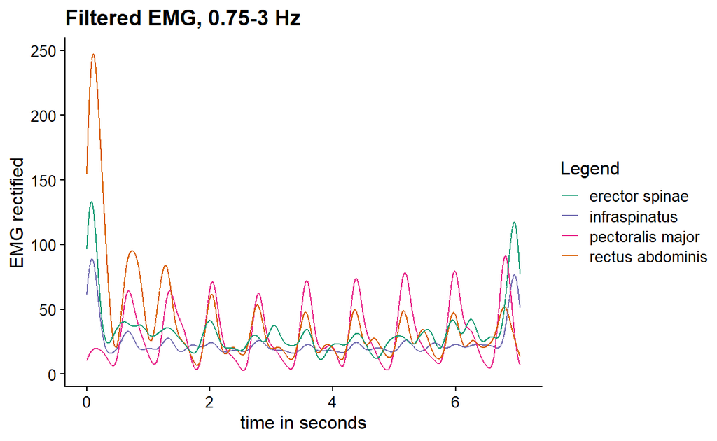

Figure 2: Example of heart rate/ECG signal’s presence in the four different EMG signals. This example is from the no movement condition.

```r
#show another example, now from no movement condition
#we use p18, trial 73
#grep("p18_trial_73_BrainAmpSeries-Dev_1.csv", EMGdata)

emgdnomov <- read.csv(paste0(rawd, EMGdata[824]))
colnames(emgdnomov) <- c('time_s', 'infraspinatus', 'rectus_abdominis', 'pectoralis_major', 'erector_spinae', 'empty1', 'empty2', 'empty3', 'empty4', 'respiration_belt', 'button_box')
samplingrate <- 1/mean(diff(emgdnomov$time_s))
nyquistemg <- samplingrate/2

emgdnomov$time_s <- emgdnomov$time_s-min(emgdnomov$time_s) # normalize time

#example with high-pass filter at 0.75 and low-pass filter 3 Hz
# cutoffhigh = high-pass filter, cutofflow = low-pass filter
emgdnomov$pectoralis_major_sm_h <- reclow.it(emgdnomov$pectoralis_major, samplingrate= samplingrate, cutoffhigh = 0.75, cutofflow = 3)
emgdnomov$infraspinatus_sm_h  <- reclow.it(emgdnomov$infraspinatus, samplingrate= samplingrate, cutoffhigh = 0.75, cutofflow = 3)
emgdnomov$erector_spinae_sm_h  <- reclow.it(emgdnomov$erector_spinae, samplingrate= samplingrate, cutoffhigh = 0.75, cutofflow = 3)
emgdnomov$rectus_abdominis_sm_h  <- reclow.it(emgdnomov$rectus_abdominis, samplingrate= samplingrate, cutoffhigh = 0.75, cutofflow = 3)

#example trial
filteredEMGnomov <- ggplot(emgdnomov[seq(1, nrow(emgdnomov),by=5),], aes(x=time_s)) +
  geom_path(aes(y=infraspinatus_sm_h, color = 'infraspinatus')) +
  geom_path(aes(y=pectoralis_major_sm_h, color = 'pectoralis major')) +
  geom_path(aes(y=rectus_abdominis_sm_h, color = 'rectus abdominis')) +
  geom_path(aes(y=erector_spinae_sm_h, color = 'erector spinae')) +
  ggtitle('Filtered EMG, 0.75-3 Hz') +
  scale_color_manual(values = colors_mus)
filteredEMGnomov <- filteredEMGnomov +
  labs(x = "time in seconds", y = "EMG rectified", color = "Legend") +
  xlab('time in seconds') +
  ylab('EMG rectified') +
  theme_cowplot(12) +
    theme(legend.position = "right")


filteredEMGnomovinfra <- ggplot(emgdnomov[seq(1, nrow(emgdnomov),by=5),], aes(x=time_s)) +
  geom_path(aes(y=infraspinatus_sm_h, color = 'infraspinatus')) +
  ggtitle('infraspinatus') +
  scale_color_manual(values = colors_mus) +
  labs(x = "time in seconds", y = "EMG rectified", color = "Legend") +
  xlab('time in seconds') +
  ylab('EMG rectified') +
  ylim(0, 150) +
  theme_cowplot(12) +
  theme(legend.position = "none")

filteredEMGnomovpec <- ggplot(emgdnomov[seq(1, nrow(emgdnomov),by=5),], aes(x=time_s)) +
  geom_path(aes(y=pectoralis_major_sm_h, color = 'pectoralis major')) +
  ggtitle('pectoralis major') +
  scale_color_manual(values = colors_mus) +
  labs(x = "time in seconds", y = "EMG rectified", color = "Legend") +
  xlab('time in seconds') +
  ylab('EMG rectified') +
  ylim(0, 150) +
  theme_cowplot(12) +
  theme(legend.position = "none")

filteredEMGnomovrectus <- ggplot(emgdnomov[seq(1, nrow(emgdnomov),by=5),], aes(x=time_s)) +
  geom_path(aes(y=rectus_abdominis_sm_h, color = 'rectus abdominis')) +
  ggtitle('rectus abdominis') +
  scale_color_manual(values = colors_mus) +
  labs(x = "time in seconds", y = "EMG rectified", color = "Legend") +
  xlab('time in seconds') +
  ylab('EMG rectified') +
  ylim(0, 150) +
  theme_cowplot(12) +
  theme(legend.position = "none")

filteredEMGnomoverector <- ggplot(emgdnomov[seq(1, nrow(emgdnomov),by=5),], aes(x=time_s)) +
  geom_path(aes(y=erector_spinae_sm_h, color = 'erector spinae')) +
  ggtitle('erector spinae') +
  scale_color_manual(values = colors_mus) +
  labs(x = "time in seconds", y = "EMG rectified", color = "Legend") +
  xlab('time in seconds') +
  ylab('EMG rectified') +
  ylim(0, 150) +
  theme_cowplot(12) +
    theme(legend.position = "none")
```

Fig.2 shows the four different, filtered EMG signals in one plot. To further inspect, which ones are more apt for studying heart rate, we have separated the signals in Fig.3.

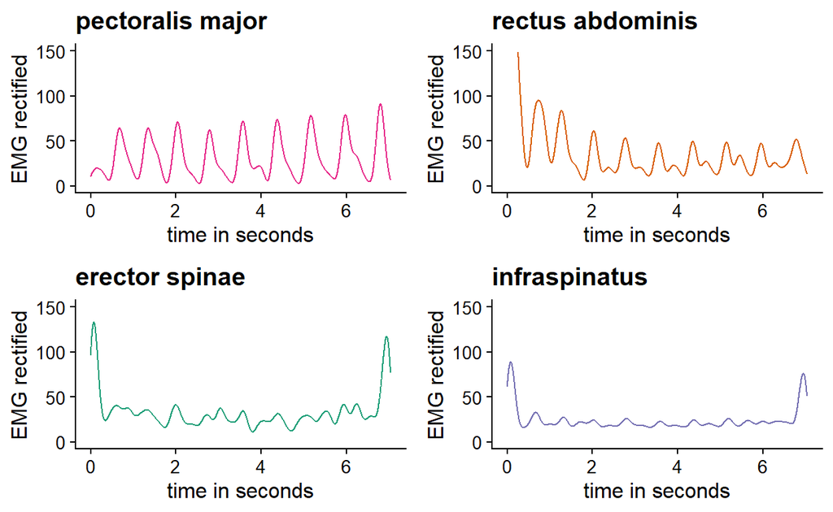

Figure 3: Example of heart rate/ECG signal’s presence in the EMG signals. The plot shows the raw rectified high-pass filtered EMG. This example shows a no movement. The heart rate peaks are especially visible in the EMG of the pectoralis major and the rectus abdominis, and less strongly in erector spinae and infraspinatus. The latter are attached on the participant’s back and more distant to the heart.

### Acoustics

For acoustics we extract the smoothed amplitude envelope (hereafter envelope). For the envelope we apply a Hilbert transform to the waveform signal, then take the complex modulus to create a 1D time series, which is then resampled at 2,500 Hz, and smoothed with a Hann filter based on a Hanning Window of 12 Hz. We normalize the amplitude envelope signals within participants before submitting to analyses.

**Show code extracting acoustics**

```r
library(rPraat) #for reading in sounds
library(dplR)   #for applying Hanning
library(seewave) #for signal processing general
library(wrassp) #for acoustic processing

##################### MAIN FUNCTION TO EXTRACT SMOOTHED ENVELOPE ###############################
amplitude_envelope.extract <- function(locationsound, smoothingHz, resampledHz)
{
  #read the sound file into R
  snd <- rPraat::snd.read(locationsound)
  #apply the hilbert on the signal
  hilb <- seewave::hilbert(snd$sig, f = snd$fs, fftw =FALSE)
  #apply complex modulus
  env <- as.vector(abs(hilb))
  #smooth with a hanning window
  env_smoothed <- dplR::hanning(x= env, n = snd$fs/smoothingHz)
  #set undeterminable at beginning and end NA's to 0
  env_smoothed[is.na(env_smoothed)] <- 0
  #resample settings at desired sampling rate
  f <- approxfun(1:(snd$duration*snd$fs),env_smoothed)
  #resample apply
  downsampled <- f(seq(from=0,to=snd$duration*snd$fs,by=snd$fs/resampledHz))
  #let function return the downsampled smoothed amplitude envelope
  return(downsampled[!is.na(downsampled)])
}
```

### Data aggregation

All signals were sampled at, or upsampled to, 2,500 Hz. Then we aggregated the data by aligning time series in a combined by-trial format to increase ease of combined analyses. We linearly interpolated signals when sample times did not align perfectly.

**Show code aggregating the data**

```r
library(pracma)
library(zoo)

overwrite = FALSE

#lets loop through the triallist and extract the files
triallist$uniquetrial <- paste0(triallist$trialindex, '_', triallist$ppn)
  #remove duplicates so that we ignore repeated trials
howmany_repeated <- sum(duplicated(triallist$uniquetrial))
triallist <- triallist[!duplicated(triallist$uniquetrial),]


for(ID in triallist$uniquetrial)
{
  #print(paste0('working on ', ID))
  #debugging
  #ID <- triallist$uniquetrial[27] #I commented that out bc it was so many lines

  triallist_s <- triallist[triallist$uniquetrial==ID,]
  ##load in row triallist
  pp <- triallist_s$ppn
  pps <- triallist_s$ppn
  if((pp == '41') | (pp == '42')){pps <- '4'}
  gender <- mtlist$sex[mtlist$ppn==pps]
  hand   <- mtlist$handedness[mtlist$ppn==pps]
  triali <- triallist_s$trialindex

  if(!file.exists(paste0(procd, 'pp_', pp, '_trial_', triali, '_aligned.csv')) | overwrite == TRUE)
  {
  ######load in EMG and resp belt
    EMGr <- read.csv(paste0(rawd, 'p', pp, '_trial_',triali, '_BrainAmpSeries-Dev_1.csv'))
    channels <- c('time_s', 'infraspinatus', 'rectus_abdominis', 'pectoralis_major', 'erector_spinae', 'empty1', 'empty2', 'empty3', 'empty4', 'respiration_belt', 'button_box')
    colnames(EMGr) <- channels
    #only keep the relevant vectors
    EMGr <- cbind.data.frame(EMGr$time_s,EMGr$respiration_belt, EMGr$infraspinatus,
                             EMGr$rectus_abdominis,EMGr$pectoralis_major, EMGr$erector_spinae)
    colnames(EMGr) <- channels[c(1, 10, 2, 3, 4, 5)] #rename
    EMGsamp <- 1/mean(diff(EMGr$time_s-min(EMGr$time_s)))
    #smooth
      #note the respiration belt is not installed now, but if we resolve technical issues we might add it
    EMGr$respiration_belt <- butter.it(EMGr$respiration_belt, samplingrate = EMGsamp, order = 2, cutoff = 30)
      #smooth EMG with described settings
    EMGr[,3:6] <- apply(EMGr[,3:6], 2, function(x) reclow.it(scale(x, scale = FALSE, center =TRUE), samplingrate= EMGsamp, cutoffhigh = 0.75, cutofflow = 3))#this was changed for getting heart from EMG; used to be high = 30, low = 20

#CHANGECONF we center before we smooth now
#########load in acoustics
  locsound <- paste0(rawd, 'p', pp, '_trial_',triali, '_Micdenoised.wav')
  if(!file.exists(locsound)){print(paste0('this mic file does not exist: ', locsound))}
  if(file.exists(locsound)){


  env <- amplitude_envelope.extract(locationsound=locsound, smoothingHz =  12, resampledHz = 2500)
  acoustics <- cbind.data.frame(env)
  acoustics$f0 <- NA
  acoustics$time_s <- seq(0, (nrow(acoustics)-1)*1/2500, 1/2500)
  duration_time <- (max(acoustics$time_s)-min(acoustics$time_s)) #note down duration time of this trial
  #########load in motion
  mt <- read.csv(paste0(rawd, 'p', pp, '_trial_',triali, '_video_raw_body.csv'))
  if(hand == 'r'){mov <- cbind.data.frame(mt$X_RIGHT_WRIST, mt$Y_RIGHT_WRIST, mt$Z_RIGHT_WRIST)}  #CHANGECONF change we also take depth
  if(hand == 'l'){mov <- cbind.data.frame(mt$X_LEFT_WRIST, mt$Y_LEFT_WRIST, mt$Z_RIGHT_WRIST)}    #CHANGECONF we also take depth
  colnames(mov) <- c('x_wrist', 'y_wrist', 'z_wrist')
  mov$y_wrist <- mov$y_wrist*-1 #flip axes so that higher up means higher values (check)
  #filter movements
  mov[,1:3] <- apply(mov[,1:3], 2, FUN=function(x) butter.it(x, order=4, samplingrate = 60, cutoff = 10, type='low'))

  #########load in balanceboard
  bb <- read.csv(paste0(rawd, 'p', pp, '_trial_',triali, '_BalanceBoard_stream.csv'))
  colnames(bb) <- c('time_s', 'left_back', 'right_forward', 'right_back', 'left_forward')
  bbsamp <- 1/mean(diff(bb$time_s - min(bb$time_s)))
  bb[,2:5] <- apply(bb[,2:5], 2, function(x) sgolayfilt(x, 5, 51))
  COPX  <- (bb$right_forward+bb$right_back)-(bb$left_forward+bb$left_back)
  COPY  <- (bb$right_forward+bb$left_forward)-(bb$left_back+bb$left_back)
  bb$COPXc <- sgolayfilt(c(0, diff(COPX)), 5, 51)
  bb$COPYc <-  sgolayfilt(c(0, diff(COPY)), 5, 51)
  bb$COPc <- sqrt(bb$COPXc^2 + bb$COPYc^2)
  #########combine everything
    #combined acoustics and EMG(+resp)
  EMGr$time_ss <- EMGr$time_s-min(EMGr$time_s)
  ac_emg <- merge(acoustics, EMGr, by.x = 'time_s', by.y = 'time_ss', all=TRUE)
  ac_emg[,4:ncol(ac_emg)] <- apply(ac_emg[,4:ncol(ac_emg)], 2, function(y) na.approx(y, x=ac_emg$time_s, na.rm = FALSE))
  #do this only for 4 EMG, name them
  ac_emg <- ac_emg[!is.na(ac_emg$env),]
  ac_emg$time_s <- ac_emg$time_s + min(ac_emg[,4],na.rm=TRUE) #get the original time
  ac_emg <- ac_emg[!is.na(ac_emg$time_s),-4] #remove the centered time variable, and remove time NA at the end
    #now add balance board
  ac_emg_bb <- merge(ac_emg, bb[,c(1, 6:8)], by.x='time_s', by.y='time_s', all= TRUE)
  ac_emg_bb[,9:11] <- apply(ac_emg_bb[,9:11], 2, function(y) na.approx(y, x=ac_emg_bb$time_s, na.rm = FALSE))
  ac_emg_bb <- ac_emg_bb[!is.na(ac_emg_bb$env), ]
  ac_emg_bb <- ac_emg_bb[!is.na(ac_emg_bb$time_s),-4]
    #now add the final motion (which is thereby upsampled to 2500 hertz)
  start_time <- min(ac_emg_bb$time_s,na.rm=TRUE)
  mov$time_s <-   start_time+seq(0, duration_time-(duration_time /nrow(mov)), by= duration_time /nrow(mov))
  ac_emg_bb_m <- merge(ac_emg_bb, mov, by.x='time_s', by.y='time_s', all = TRUE)
  ac_emg_bb_m[,11:13] <- apply(ac_emg_bb_m[,11:13], 2, function(y) na.approx(y, x=ac_emg_bb_m$time_s, na.rm = FALSE))
  ac_emg_bb_m <- ac_emg_bb_m[!is.na(ac_emg_bb_m$env), ]
  #now write the files away to a processed folder
  write.csv(ac_emg_bb_m, paste0(procd, 'pp_', pp, '_trial_', triali, '_heartrate', '_aligned.csv')) #added heartrate to the name, so it doesn't create problems with the other files
    }
  }
}
```

### Data sharing & Privacy

Video data is deidentified using the masked-piper tool to mask faces and body while maintaining kinematic information (Owoyele et al. 2022).

## Overview data analyses

**Show code scaling data within participant**

```r
#We have to do some within participant scaling, such that
  #all EMG's are rescaled within trials
fs <-  list.files(procd)
fs <- fs[!fs%in%list.files(procd, pattern = 'zscal_*')]
fs <- fs[fs%in%list.files(procd, pattern = "heartrate")]

#set to true if you want to overwrite files (to check [modified] code)
overwrite = FALSE

if((length(list.files(procd, pattern = 'zscal_*')) == 0) | (overwrite==TRUE))
{
  mr <- data.frame()
  for(f in fs)
  {
    temp <- read.csv(paste0(procd, f))
    temp$pp <- parse_number(f)
    temp$tr <- f
    mr <- rbind.data.frame(mr, temp)
  }

  #set ppn to 4
  temp$pp[temp$pp==41 | temp$pp==42] <- 4

  # #center the muscle measurements for each trial (due to drift)
  # mr$infraspinatus <- ave(mr$infraspinatus, mr$tr, FUN = function(x){x<-x-mean(x, na.rm=TRUE)})
  # mr$rectus_abdominis <- ave(mr$rectus_abdominis, mr$tr, FUN = function(x){x<-x-mean(x, na.rm=TRUE)})
  # mr$pectoralis_major <- ave(mr$pectoralis_major, mr$tr, FUN = function(x){x<-x-mean(x, na.rm=TRUE)})
  # mr$erector_spinae <- ave(mr$erector_spinae, mr$tr, FUN = function(x){x<-x-mean(x, na.rm=TRUE)})

  #we normalize signals by trial and detrend the 2 EMG signals; we will normalize them by the part from 1 to 6 s, for which we first need the time


  #save the scaled variables in new objects
  for(f in unique(mr$tr))
  {
    sb <- mr[mr$tr==f, ]
    sb$time_s  <- sb$time_s #this is the time
    sb$time_s_c <- sb$time_s-min(sb$time_s)# accumulating at trial start (resyncing) resynced with the psychopy  software

  #detrend
  sb$rectus_abdominis <- ave(sb$rectus_abdominis, sb$tr, FUN = function(x){pracma::detrend(x, tt = 'linear')})
  sb$pectoralis_major <- ave(sb$pectoralis_major, sb$tr, FUN = function(x){pracma::detrend(x, tt = 'linear')})

  #use mean and sd from 1 to 6 s for scaling
  sbscale <- sb %>%
     dplyr::filter(time_s_c > 1 & time_s_c < 6)
  rectus_mean <- mean(sbscale$rectus_abdominis)
  rectus_sd <- sd(sbscale$rectus_abdominis)
  pectoralis_mean <- mean(sbscale$pectoralis_major)
  pectoralis_sd <- sd(sbscale$pectoralis_major)

  #center the 2 signals
  # sb$pectoralis_major <- ave(sb$pectoralis_major, sb$tr, FUN = function(x){x<-x-mean(x, na.rm=TRUE)})
  # sb$rectus_abdominis <- ave(sb$rectus_abdominis, sb$tr, FUN = function(x){x<-x-mean(x, na.rm=TRUE)})

  #now scale & center the 2 EMG signals by using these values
  sb$rectus_abdominis <- ave(sb$rectus_abdominis, sb$tr, FUN = function(x){x <- (x - rectus_mean) / rectus_sd})
  sb$pectoralis_major <- ave(sb$pectoralis_major, sb$tr, FUN = function(x){x <- (x - pectoralis_mean) / pectoralis_sd})

  #mr$erector_spinae <- ave(mr$erector_spinae, mr$tr, FUN = function(x)scale(x, center = T))
  sb$env_z <- ave(sb$env, sb$tr, FUN = function(x)scale(x, center = T))

    #subset
    #center motion per trial
    #sb$x_wrist <- sb$x_wrist-mean(sb$x_wrist,na.rm=TRUE)
    #sb$y_wrist <- sb$y_wrist-mean(sb$y_wrist,na.rm=TRUE)
    #sp <- c(0, sqrt(diff(sb$x_wrist)^2+diff(sb$y_wrist)^2))
    #sp[is.na(sp)] <- 0 #there are some trailing NA's which we fill with 0
    #sb$speed <- butter.it(sp, samplingrate = 2500, order = 4, cutoff = 5)
    write.csv(sb, paste0(procd, 'zscal_', f))
  }
}
```

**Show code producing the plot**

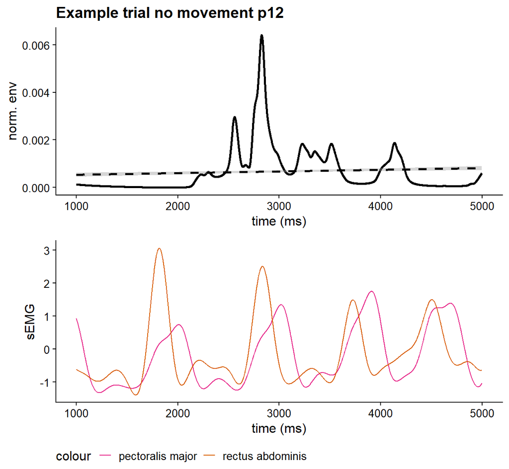

Figure 4: Combined time series. One example trial and the associated EMG signals are shown, for the no movement condition with vocalization. We determine a detrending line using linear regression for the 1 to 5 s after the vocalization prompt.

```r
ptest=12
ex2 <- triallist[triallist$vocal_condition=='expire' & triallist$movement_condition=='no_movement'& triallist$ppn ==ptest, ]
ex2 <- ex2[1, ]
#ex2$trialindex
if (file.exists(paste0(procd, 'zscal_pp_', ex2$ppn, '_trial_', ex2$trialindex, '_heartrate_aligned.csv')))
{
exts2 <- read.csv(paste0(procd, 'zscal_pp_', ex2$ppn, '_trial_', ex2$trialindex, '_heartrate_aligned.csv'))
#exts2 <- dplyr::rename(exts2, rectus_abdominis = rectus_abdominus)
  exts2 <- subset(exts2, time_s_c > 1 & time_s_c <5)
  exts2 <- exts2[seq(1, nrow(exts2), by = 5), ]    #downsample by a 5th
  exts2$time_ms <- round(exts2$time_s_c*1000)
  # fp <- pracma::findpeaks(exts2$speed)
  # fp <- fp[which.max(fp[,1]),]
  # startmov <- exts2$time_ms[fp[3]]
  # endmov   <- exts2$time_ms[fp[4]]
  # ps       <- exts2$time_ms[fp[2]]
#apply movement rule to centralize trials
#here all processing steps are performed, and data aligned
exampleenvelope <- ggplot(exts2, aes(x=time_ms)) +
  geom_path(aes(y=env), size =1) +
  theme_cowplot(12) +
  ggtitle('Example trial no movement p12') +
  ylab('norm. env') +
  geom_smooth(aes(y=env), method='lm', linetype = 'dashed',color = 'black') +
  xlim(1000, 5000) +
  xlab('time (ms)')


exampleEMG <- ggplot(exts2, aes(x=time_ms)) +
  #geom_path(aes(y=infraspinatus, color = 'infraspinatus')) +
  geom_path(aes(y=pectoralis_major, color = 'pectoralis major')) +
  geom_path(aes(y=rectus_abdominis, color = 'rectus abdominis')) +
  #geom_path(aes(y=erector_spinae, color = 'erector spinae')) +
  scale_color_manual(values = colors_mus) +
  labs(y="sEMG") +
  theme_cowplot(12) +
  theme(legend.position = "bottom") +
  xlim(1000, 5000) +
  xlab('time (ms)')
}
```

Fig.5 shows the vocal amplitude and two EMG signals (pectoralis major, rectus abdominis) together, again in the no movement condition, but now for participant 8.

**Show code producing the plot**

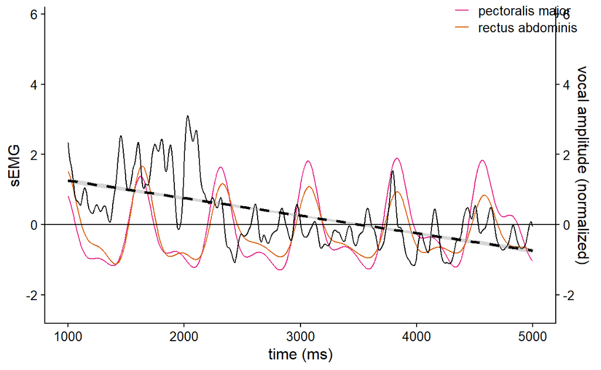

Figure 5: Example trial showing no movement and the EMG signals for pectoralis major and rectus abdominis.

```r
#ptest=8
ex3 <- triallist %>%
  dplyr::filter(vocal_condition == "expire") %>%
  dplyr::filter(movement_condition == "no_movement") %>%
  dplyr::filter(ppn == 8) #arbitrary but we also chose ppn 8 in the example above
ex3 <- ex3[2, ]
#ex2$trialindex
if (file.exists(paste0(procd, 'zscal_pp_', ex3$ppn, '_trial_', ex3$trialindex, '_heartrate_aligned.csv')))
{
exts3 <- read.csv(paste0(procd, 'zscal_pp_', ex3$ppn, '_trial_', ex3$trialindex, '_heartrate_aligned.csv'))
#exts2 <- dplyr::rename(exts2, rectus_abdominis = rectus_abdominus)
  exts3 <- subset(exts3, time_s_c > 0 & time_s_c <7)
  exts3 <- exts3[seq(1, nrow(exts3), by = 5), ]    #downsample by a 5th
  exts3$time_ms <- round(exts3$time_s_c*1000)
  #fp <- pracma::findpeaks(exts3$speed)
  #fp <- fp[which.max(fp[,1]),]
  #startmov <- exts3$time_ms[fp[3]]
  #endmov   <- exts3$time_ms[fp[4]]
  #ps       <- exts3$time_ms[fp[2]]
#apply movement rule to centralize trials
#here all processing steps are performed, and data aligned


examplenomov <- ggplot(exts3, aes(x=time_ms)) +
  geom_path(aes(y=scale(pectoralis_major), color = 'pectoralis major')) +
  geom_path(aes(y=scale(rectus_abdominis), color = 'rectus abdominis')) +
  geom_path(aes(y=scale(env)), color="black") +
  geom_smooth(aes(y=scale(env)), method='lm', linetype = 'dashed',color = 'black') +
  scale_color_manual(values = colors_mus) +
  scale_y_continuous(
    name = "sEMG",
    sec.axis = sec_axis(~., name="vocal amplitude (normalized)")
  ) +
  theme_cowplot(12) +
  theme(legend.position = c(0.8, 1)) +
  geom_hline(yintercept= 0) +
  xlim(1000, 5000) +
  xlab('time (ms)')

}
```

**Show code producing the plot**

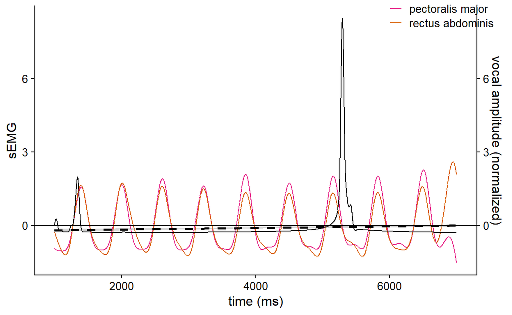

Figure 6: Example trial (no movement condition) showing the vocal amplitude and the respective trendline (black), as well as the EMG signals for pectoralis major and rectus abdominis.

```r
#ptest=8

ex4 <- triallist %>%
  dplyr::filter(vocal_condition == "expire") %>%
  dplyr::filter(movement_condition == "no_movement") %>%
  dplyr::filter(ppn == 10) #arbitrary but we also chose ppn 8 in the example above
ex4 <- ex4[3, ]
#ex2$trialindex
if (file.exists(paste0(procd, 'zscal_pp_', ex4$ppn, '_trial_', ex4$trialindex, '_heartrate_aligned.csv')))
{
exts4 <- read.csv(paste0(procd, 'zscal_pp_', ex4$ppn, '_trial_', ex4$trialindex, '_heartrate_aligned.csv'))
#exts2 <- dplyr::rename(exts2, rectus_abdominis = rectus_abdominus)
  exts4 <- subset(exts4, time_s_c > 0 & time_s_c <7)
  exts4 <- exts4[seq(1, nrow(exts4), by = 5), ]    #downsample by a 5th
  exts4$time_ms <- round(exts4$time_s_c*1000)

examplenomov2 <- ggplot(exts4, aes(x=time_ms)) +
  #geom_path(aes(y=infraspinatus, color = 'infraspinatus')) +
  geom_path(aes(y=scale(pectoralis_major), color = 'pectoralis major')) +
  geom_path(aes(y=scale(rectus_abdominis), color = 'rectus abdominis')) +
  geom_path(aes(y=scale(env)), color="black") +
  geom_smooth(aes(y=scale(env)), method='lm', linetype = 'dashed',color = 'black') +
  scale_color_manual(values = colors_mus) +
  scale_y_continuous(
    name = "sEMG",
    sec.axis = sec_axis(~., name="vocal amplitude (normalized)")
  ) +
  theme_cowplot(12) +
  theme(legend.position = c(0.8, 1)) +
  geom_hline(yintercept= 0) +
  xlim(1000, 7000) +
  xlab('time (ms)')
}
```

**Show code producing the plot**

```r
numnomovement_vocalize <- triallist %>%
  dplyr::filter(vocal_condition == "vocalize") %>%
  dplyr::filter(movement_condition == "no_movement") %>%
  dplyr::filter(trial_type == "main")

numnomovement_expire <- triallist %>%
  dplyr::filter(vocal_condition == "expire") %>%
  dplyr::filter(movement_condition == "no_movement") %>%
  dplyr::filter(trial_type == "main")
```

In total, there are 128 trials from the no movement condition with voicing. From the expiration condition, which we will not use here, there are 129 no movement trials.

From the z-scored envelope, we calculate velocity of the envelope. This is then used to find and locate the first peak in velocity, which is the onset of vocalization. We then locate the closest peaks in the EMG signal of the pectoralis major and the rectus abdominis. The number of peaks in those EMG signals in the recorded time span is also used to calculate a participant’s heart rate.

As a next step, we de-trend the amplitude envelope using the package pracma. We do this on the envelope time series from 1 to 6 s to avoid any late starts or early finishes to mess with the de-trending line.

**Show code setting up the data frame**

```r
#just inserted the cache.lazy, because I could not knit (long vectors not supported yet)

overwrite = FALSE

if(overwrite==TRUE)
{
#filter out all trials related to movement, expiration, or practice
triallist_nomov <- triallist %>%
  dplyr::filter(movement_condition == "no_movement") %>%
  dplyr::filter(vocal_condition == "expire") %>%
  dplyr::filter(trial_type == "main")
tr_wd_nomov <- triallist_nomov
tr_wd_nomov$highest_veloc_peak_time <- NA

#lets loop through the triallist and extract the files
tr_wd_nomov$uniquetrial <- paste0(tr_wd_nomov$trialindex, '_', triallist_nomov$ppn)
  #remove duplicates so that we ignore repeated trials #NOTE in total we registered 25 repeats
howmany_repeated <- sum(duplicated(tr_wd_nomov$uniquetrial))
tr_wd_nomov <- tr_wd_nomov[!duplicated(tr_wd_nomov$uniquetrial),]

#make one large dataset
tsl <- data.frame()
tsl_fulltime <- data.frame() #this one exists so we have EMG signals without the time constraints (1-6s) we need for the detrending in the other one

for(ID in tr_wd_nomov$uniquetrial)
{
  #ID <- tr_wd$uniquetrial[27]
  tr_wd_s <- tr_wd_nomov[tr_wd_nomov$uniquetrial==ID,]

  ##load in row tr_wd
  pp <- tr_wd_s$ppn
  gender <- mtlist$sex[mtlist$ppn==pp]
  hand   <- mtlist$handedness[mtlist$ppn==pp]
  triali <- tr_wd_s$trialindex
  if(file.exists(paste0(procd, 'zscal_pp_', pp, '_trial_', triali, '_heartrate_aligned.csv')))
  {
  ts <- read.csv(paste0(procd, 'zscal_pp_', pp, '_trial_', triali, '_heartrate_aligned.csv'))

  ts$time_ms <- round(ts$time_s*1000)
  ts$time_ms <- ts$time_ms-min(ts$time_ms)
  ts$uniquetrial <- paste0(triali, "_", pp)

### before detrending, we want to find the onset of vocalization, for which we use the peak velocity of the envelope

#get velocity first
  ts$env_z_veloc <- c(0, diff(ts$env_z))

#then get the peaks
  velocitypeaks <- pracma::findpeaks(ts$env_z_veloc)
  highest_veloc_peak <- velocitypeaks[which.max(velocitypeaks[, 1])]  #find highest peak in col 1
  corresponding_time_index <- which(ts$env_z_veloc == highest_veloc_peak)[1] #find index of that highest peak in velocity data
  tr_wd_nomov$highest_veloc_peak_time[tr_wd_nomov$uniquetrial==ID] <- ts$time_ms[corresponding_time_index] #use that index to extract time value from dataframe

#now find peaks in rectus & pectoralis EMG signal
  #start with rectus
  rectuspeaks <- pracma::findpeaks(ts$rectus_abdominis) #find peaks in rectus signal
  rectuspeak_times <- numeric(length(rectuspeaks[, 1])) #create a vector length of number of peaks
  for (i in seq_len(nrow(rectuspeaks))) { #find the according peak times
    peak_index <- rectuspeaks[i, 2]
    rectuspeak_times[i] <- ts$time_ms[peak_index]
  }

  #now do the same for pectoralis
  pectoralispeaks <- pracma::findpeaks(ts$pectoralis_major) #find peaks in pectoralis signal
  pectoralispeak_times <- numeric(length(pectoralispeaks[, 1])) #create a vector length of number of peaks
  for (i in seq_len(nrow(pectoralispeaks))) { #find the according peak times
    peak_index <- pectoralispeaks[i, 2]
    pectoralispeak_times[i] <- ts$time_ms[peak_index]
  }

  #drop columns not needed for the analysis done here (heart rate)
  ts <- ts %>%
    select(!c(X.1, X, f0, time_s, infraspinatus, erector_spinae, COPXc, COPYc, COPc, x_wrist, y_wrist, z_wrist))

  subts <- ts
  subts$movement_condition <- tr_wd_s$movement_condition
  subts$vocal_condition <- tr_wd_s$vocal_condition
  subts$weight_condition <- tr_wd_s$weight_condition
  subts$trial_number <-  tr_wd_s$trialindex

  #store this in tsl_fulltime, which we need for EMG calculations without time restrictions
  tsl_fulltime <- rbind(tsl_fulltime, subts)

  #now create tsl, where we shorten the time span, so we can detrend
  #take the first 1 to 6 seconds
  ts <- ts[(ts$time_ms>1000) & (ts$time_ms < 6000), ]

  ts$env_z_detrend <- pracma::detrend(ts$env_z, tt = 'linear') # detrend the envelope

  subts <- ts
  subts$movement_condition <- tr_wd_s$movement_condition
  subts$vocal_condition <- tr_wd_s$vocal_condition
  subts$weight_condition <- tr_wd_s$weight_condition
  subts$trial_number <-  tr_wd_s$trialindex

  #bind into big dataset
  tsl <- rbind(tsl, subts)

  tsl <- tsl %>%
    dplyr::filter(movement_condition == "no_movement")
  #to make it faster, we here filter by movement condition == no movement, since we're only using that one here anyways

  }
}

#write to file if overwrite == T
write.csv(tr_wd_nomov, paste0(procdtot, 'fulldata_heartrate.csv'))
write.csv(tsl, paste0(procdtot, 'time_series_all_heartrate.csv'))
write.csv(tsl_fulltime, paste0(procdtot, 'time_series_all_heartrate_fulltime.csv'))

}
#read this in
if(overwrite==FALSE)
{
  tr_wd_nomov <- read.csv(paste0(procdtot, 'fulldata_heartrate.csv'))
  tsl   <- read.csv(paste0(procdtot, 'time_series_all_heartrate.csv'))
  tsl_fulltime <-read.csv(paste0(procdtot, 'time_series_all_heartrate_fulltime.csv'))
}

tsl_fulltime <- tsl_fulltime %>%
  dplyr::filter(movement_condition == "no_movement")
tsl_fulltime$pectoralis_major[is.na(tsl_fulltime$pectoralis_major)] <- 0 #there are some trailing NA's which we fill with 0
tsl_fulltime$rectus_abdominis[is.na(tsl_fulltime$rectus_abdominis)] <- 0

tr_wd$ppn <- ifelse(tr_wd$ppn%in%c(41, 42), 4, tr_wd$ppn)
```

To make sure that all participants show heart rate in the EMG measured on the anterior side of their body, we will here visualize them all.

```r
nomovement <- tsl %>%
  dplyr::filter(vocal_condition == "expire") %>%
  dplyr::filter(movement_condition == "no_movement")

nomovement <- nomovement %>%
  mutate(pptrial = stringr::str_replace(uniquetrial, "(\\d+)_+(\\d+)", "\\2_\\1"))

#example trial
filteredEMGnomovdetrended <- ggplot(nomovement[seq(1, nrow(nomovement),by=5),], aes(x=time_ms, group = tr)) +
  geom_path(aes(y=pectoralis_major, color = 'pectoralis major')) +
  geom_path(aes(y=rectus_abdominis, color = 'rectus abdominis')) +
  ggtitle('Filtered EMG, 0.5-5 Hz') +
  scale_color_manual(values = colors_mus)
filteredEMGnomov <- filteredEMGnomov +
  labs(x = "time in seconds", y = "EMG rectified", color = "Legend") +
  xlab('time in seconds') +
  ylab('EMG rectified') +
  theme_cowplot(12) +
    theme(legend.position = "right")


filteredEMGnomovpec <- ggplot(emgdnomov[seq(1, nrow(emgdnomov),by=5),], aes(x=time_s)) +
  geom_path(aes(y=pectoralis_major_sm_h, color = 'pectoralis major')) +
  ggtitle('pectoralis major') +
  scale_color_manual(values = colors_mus) +
  labs(x = "time in seconds", y = "EMG rectified", color = "Legend") +
  xlab('time in seconds') +
  ylab('EMG rectified') +
  ylim(0, 150) +
  theme_cowplot(12) +
  theme(legend.position = "none")

filteredEMGnomovrectus <- ggplot(emgdnomov[seq(1, nrow(emgdnomov),by=5),], aes(x=time_s)) +
  geom_path(aes(y=rectus_abdominis_sm_h, color = 'rectus abdominis')) +
  ggtitle('rectus abdominis') +
  scale_color_manual(values = colors_mus) +
  labs(x = "time in seconds", y = "EMG rectified", color = "Legend") +
  xlab('time in seconds') +
  ylab('EMG rectified') +
  ylim(0, 150) +
  theme_cowplot(12) +
  theme(legend.position = "none")
```

**Show code producing the plot**

```r
ex5 <- subset(nomovement, tr == "pp_10_trial_36_heartrate_aligned.csv")


#normalize
ex5$pectoralis_major  <- scale(ex5$pectoralis_major)
ex5$rectus_abdominis  <- scale(ex5$rectus_abdominis)

#exts5 <- subset(ex5, time_s_c > 0 & time_s_c <7)
#exts5 <- exts5[seq(1, nrow(exts5), by = 5), ]    #downsample by a 5th
ex5$time_ms <- round(ex5$time_s_c*1000)


examplenomov3 <- ggplot(ex5, aes(x=time_ms)) +
  #geom_path(aes(y=infraspinatus, color = 'infraspinatus')) +
  geom_path(aes(y=scale(pectoralis_major), color = 'pectoralis major')) +
  geom_path(aes(y=scale(rectus_abdominis), color = 'rectus abdominis')) +
  geom_path(aes(y=env_z_detrend), color="black") +
  geom_smooth(aes(y=env_z_detrend), method='lm', linetype = 'dashed',color = 'black') +
  scale_color_manual(values = colors_mus) +
  scale_y_continuous(
    name = "sEMG",
    sec.axis = sec_axis(~., name="vocal amplitude (normalized)")
  ) +
  #labs(y="sEMG") +
  theme_cowplot(12) +
  theme(legend.position = c(0.8, 1)) +
  geom_hline(yintercept= 0) +
  xlim(0, 7000) +
  xlab('time (ms)')

examplenomovveloc3 <- ggplot(ex5, aes(x=time_ms)) +
  #geom_path(aes(y=infraspinatus, color = 'infraspinatus')) +
  geom_path(aes(y=env_z_veloc), color="black") +
  scale_color_manual(values = colors_mus) +
  scale_y_continuous(
    name = "sEMG",
    sec.axis = sec_axis(~., name="vocal amplitude (normalized)")
  ) +
  #labs(y="sEMG") +
  theme_cowplot(12) +
  theme(legend.position = c(0.8, 1)) +
  geom_hline(yintercept= 0) +
  xlim(0, 7000) +
  xlab('time (ms)')
```

[figure not shown]

Let’s also visualize all the detrended envelope amplitudes. As in our data, participants were given the cue to start vocalizing at time = 0 s, we should check when they start vocalizing.

**Show code producing the plot**

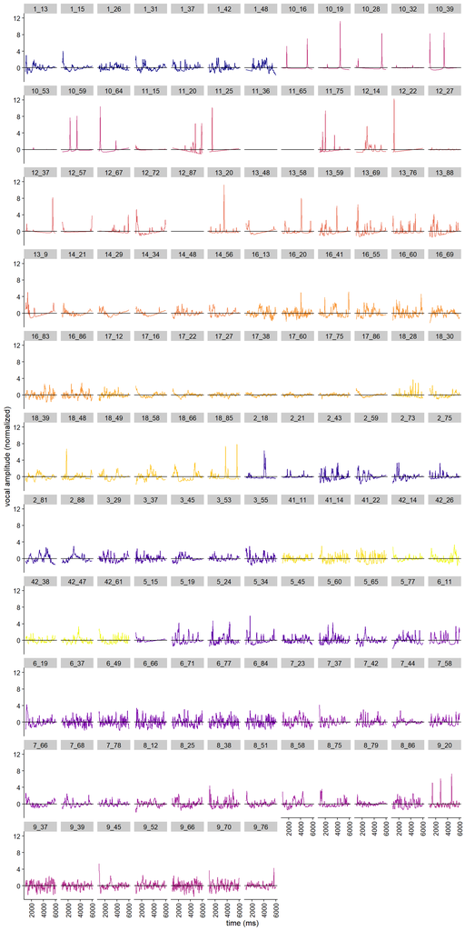

```r
nomovement$pp <- as.factor(nomovement$pp)

allenvelopes <- ggplot(nomovement, aes(x=time_ms)) +
  geom_path(aes(y=env_z_detrend, color=pp)) +  scale_y_continuous(name = "vocal amplitude (normalized)") +
  theme_cowplot(12) +
  theme(legend.position = c(0.8, 1)) +
  geom_hline(yintercept= 0) +
  xlim(1000, 6000) +
  xlab('time (ms)') +
  theme(legend.position = "none",
        axis.text.x = element_text(angle = 90, vjust = 0.5, hjust=1)) +
  facet_wrap(~pptrial) +
  scale_colour_viridis_d(option = "plasma")
```

**Show code producing the plot**

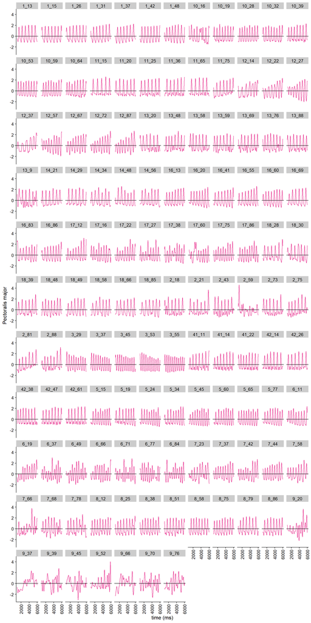

```r
allpectoralis <- ggplot(nomovement, aes(x=time_ms)) +
  geom_path(aes(y=pectoralis_major, color='pectoralis major')) +
  scale_color_manual(values = colors_mus) +
  scale_y_continuous(name = "Pectoralis major") +
  #labs(y="sEMG") +
  theme_cowplot(12) +
  theme(legend.position = c(0.8, 1)) +
  geom_hline(yintercept= 0) +
  xlim(1000, 6000) +
  xlab('time (ms)') +
  theme(legend.position = "none",
        axis.text.x = element_text(angle = 90, vjust = 0.5, hjust=1)) +
  facet_wrap(~pptrial)
```

**Show code producing the plot**

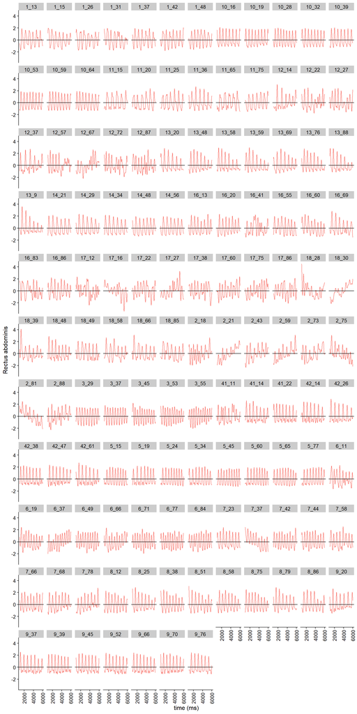

```r
allrectus <- ggplot(nomovement, aes(x=time_ms)) +
  geom_path(aes(y=rectus_abdominis, color="rectus abdominis")) +
  #scale_color_manual(values = colors_mus) +
  scale_y_continuous(name = "Rectus abdominis") +
  #labs(y="sEMG") +
  theme_cowplot(12) +
  theme(legend.position = c(0.8, 1)) +
  geom_hline(yintercept= 0) +
  xlim(1000, 6000) +
  xlab('time (ms)') +
  theme(legend.position = "none",
        axis.text.x = element_text(angle = 90, vjust = 0.5, hjust=1)) +
  facet_wrap(~pptrial)
```

**Show code producing the plot**

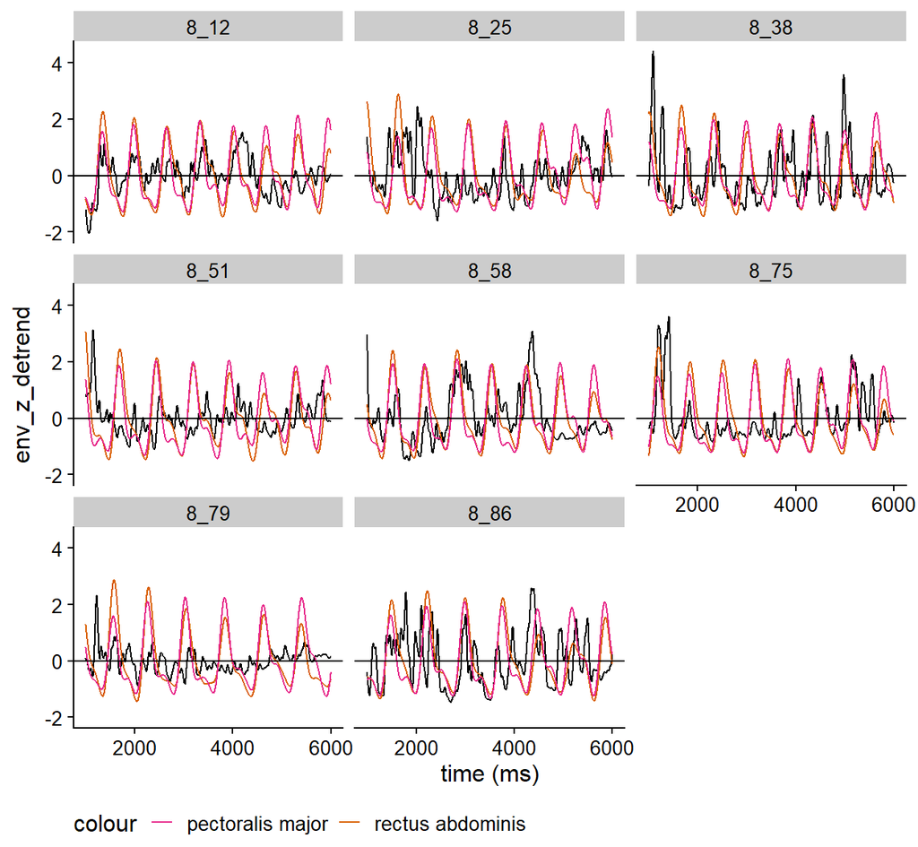

Figure 11: Amplitude envelope (black), as well as EMG signals of pectoralis major (purple) and rectus abdominis (orange) for participant 8.

```r
exampleparticipant <- nomovement %>%
  dplyr::filter(pp == "8") %>%
  ggplot(aes(x=time_ms)) +
  geom_path(aes(y=env_z_detrend), color="black") +
  #geom_smooth(aes(y=env_z_detrend, color="black"), method='lm', linetype = 'dashed') +
  geom_path(aes(y=rectus_abdominis, color = 'rectus abdominis')) +
  geom_path(aes(y=pectoralis_major, color = 'pectoralis major')) +
  #scale_y_continuous(name = "vocal amplitude (normalized)") +
  #labs(y="sEMG") +
  theme_cowplot(12) +
  scale_color_manual(values = colors_mus) +
  geom_hline(yintercept= 0) +
  xlim(1000, 6000) +
  xlab('time (ms)') +
  theme(legend.position = "bottom") +
  facet_wrap(~pptrial)
```

**Show code using FFTs to calculate heartrate on EMG signals**

```r
df_fft <- data.frame()
overwrite = FALSE #set to true if you want to run this chunk

if(overwrite == TRUE)
{
for(ID in tr_wd_nomov$uniquetrial)
{
tr_wd_s <- tr_wd_nomov[tr_wd_nomov$uniquetrial==ID,]

  ##load in row tr_wd
  pp <- tr_wd_s$ppn
  gender <- mtlist$sex[mtlist$ppn==pp]
  hand   <- mtlist$handedness[mtlist$ppn==pp]
  triali <- tr_wd_s$trialindex
  if(file.exists(paste0(procd, 'zscal_pp_', pp, '_trial_', triali, '_heartrate_aligned.csv')))
  {
  tsEMG <- read.csv(paste0(procd, 'zscal_pp_', pp, '_trial_', triali, '_heartrate_aligned.csv'))

  tsEMG$time_ms <- round(tsEMG$time_s*1000)
  tsEMG$time_ms <- tsEMG$time_ms-min(tsEMG$time_ms)
  tsEMG$uniquetrial <- paste0(triali, "_", pp)

  #before scaling/detrending, cut the signal -> 1 to 6 s (same for rectus)
  tsEMG <- tsEMG[(tsEMG$time_ms>1000) & (tsEMG$time_ms < 6000), ]
  ### start the FFT
  #rectus first
    #remove NAs
  tsEMG <- tsEMG %>%
    tidyr::drop_na(rectus_abdominis)
  NEMG = length(tsEMG$rectus_abdominis)

  #normalize and center again before the EMG is done
  #normalize signals by trial
  #also detrend
  tsEMG$rectus_abdominis[is.na(tsEMG$rectus_abdominis)] <- 0 #if there's trailing NAs, remove them
   tsEMG$rectus_abdominis <- ave(tsEMG$rectus_abdominis, tsEMG$uniquetrial, FUN = function(x){pracma::detrend( tsEMG$rectus_abdominis, tt = 'linear')})
   tsEMG$rectus_abdominis <- ave(tsEMG$rectus_abdominis, tsEMG$uniquetrial, FUN = function(x){scale(x, center = T, scale = T)})

  fftrectus <- abs(fft(tsEMG$rectus_abdominis))

  dffftrectus <- data.frame(Values = fftrectus)
  index <- 0:(length(fftrectus) -1) #start with 0, so the first bin is for 0 Hz
  dffftrectus$index <- index
  dffftrectus$frequency <- dffftrectus$index * samplingrate / NEMG
  #now cut it in half
  half_rows_rectus <- nrow(dffftrectus) %/% 2
  #subset the dataframe to keep only the first half of the rows
  dffftrectus <- dffftrectus[1:half_rows_rectus, ]

  maxfreqrectus <- dffftrectus$frequency[which.max(dffftrectus$Values)]
  tr_wd_nomov$heartrate_rectusfft_bpm[tr_wd_nomov$uniquetrial==ID] <- maxfreqrectus * 60
  tr_wd_nomov$heartrate_rectusfft_hz[tr_wd_nomov$uniquetrial==ID] <- maxfreqrectus

  #run the same for pectoralis
    #remove NAs
  tsEMG <- tsEMG %>%
    tidyr::drop_na(pectoralis_major)
  NEMG = length(tsEMG$pectoralis_major)

  #normalize and center again before the EMG is done


  #normalize signals by trial
  #also detrend
  tsEMG$pectoralis_major[is.na(tsEMG$pectoralis_major)] <- 0
  tsEMG$pectoralis_major <- ave(tsEMG$pectoralis_major, tsEMG$uniquetrial, FUN = function(x){pracma::detrend(tsEMG$pectoralis_major, tt = 'linear')})
  tsEMG$pectoralis_major <- ave(tsEMG$pectoralis_major, tsEMG$uniquetrial, FUN = function(x){scale(x, center = T, scale = T)})


  fftpectoralis <- abs(fft(tsEMG$pectoralis_major))

  dffftpectoralis <- data.frame(Values = fftpectoralis)
  index <- 0:(length(fftpectoralis) -1) #start with 0, so the first bin is for 0 Hz
  dffftpectoralis$index <- index
  dffftpectoralis$frequency <- dffftpectoralis$index * samplingrate / NEMG
  #now cut it in half
  half_rows_pectoralis <- nrow(dffftpectoralis) %/% 2
  #subset the dataframe to keep only the first half of the rows
  dffftpectoralis <- dffftpectoralis[1:half_rows_pectoralis, ]

  maxfreqpectoralis <- dffftpectoralis$frequency[which.max(dffftpectoralis$Values)]
  tr_wd_nomov$heartrate_pectoralisfft_bpm[tr_wd_nomov$uniquetrial==ID] <- maxfreqpectoralis * 60
  tr_wd_nomov$heartrate_pectoralisfft_hz[tr_wd_nomov$uniquetrial==ID] <- maxfreqpectoralis
#store the values in df_fft
  dffftrectus <- dffftrectus %>%
    rename(rectus = Values) %>%
    select(index, frequency, everything())
  dffftpectoralis <- dffftpectoralis %>%
    rename(pectoralis = Values) %>%
    select(index, frequency, everything())


  df_fft_temp <- left_join(dffftrectus, dffftpectoralis, by = c("index", "frequency"))
  df_fft_temp$uniquetrial <- paste0(triali, "_", pp)
    df_fft_temp <-df_fft_temp %>%
    mutate(pptrial = stringr::str_replace(uniquetrial, "(\\d+)_+(\\d+)", "\\2_\\1"))

  df_fft_temp <- df_fft_temp %>%
    dplyr::filter(frequency <= 3.0)

  df_fft <- rbind(df_fft, df_fft_temp)

  }
  write.csv(tr_wd_nomov, paste0(procdtot, 'fulldata_heartrate.csv'))
  write.csv(df_fft, paste0(procdtot, 'fulldata_heartrate_fft.csv'))
}
}

if(!overwrite)
{
  tr_wd_nomov <- read.csv(paste0(procdtot, 'fulldata_heartrate.csv'))
  df_fft <- read.csv(paste0(procdtot, 'fulldata_heartrate_fft.csv'))
}

#get heartrate from pectoralis FFTs, unless participant is 9, then use rectus

tr_wd_nomov <- tr_wd_nomov %>%
  mutate(heartrate_EMG_hz = ifelse(ppn == 9, heartrate_rectusfft_hz, heartrate_pectoralisfft_hz))

tr_wd_nomov <- tr_wd_nomov %>%
  mutate(heartrate_EMG_bpm = if_else(ppn == 9, heartrate_rectusfft_bpm, heartrate_pectoralisfft_bpm))
```

We can now visualize all the FFTs by participant. The frequency with the highest magnitude is what we will later use as their heartrate, after multiplying it by 60 to convert it to bpm, which is more common for heartrates.

**Show code creating the plot**

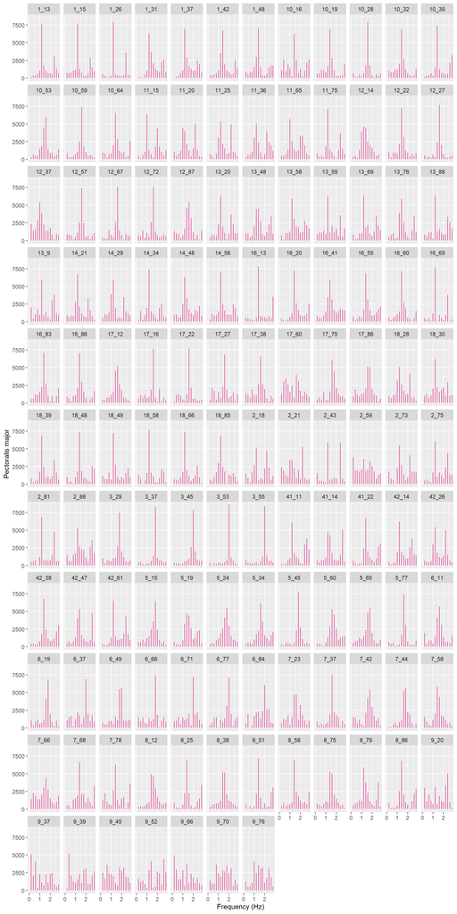

Figure 12: All spectra for the pectoralis major EMG signals (via FFT) by all participants shown in one plot..

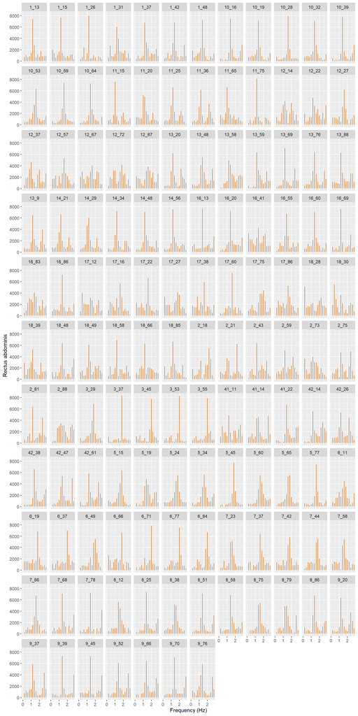

Figure 13: All spectra for the rectus abdominis EMG signals (via FFT) by all participants shown in one plot..

```r
fftplot_rectus <- ggplot(df_fft, aes(x=frequency))+
  geom_col(aes(y=rectus, color = 'rectus abdominis')) +
  scale_y_continuous(name = "Rectus abdominis") +
  scale_color_manual(values = colors_mus) +
  #labs(y="sEMG") +
  #theme_cowplot(12) +
  xlab('Frequency (Hz)') +
  theme(legend.position = "none") +
  facet_wrap(~pptrial)

fftplot_pectoralis <- ggplot(df_fft, aes(x=frequency))+
  geom_col(aes(y=pectoralis, color = 'pectoralis major')) +
  scale_y_continuous(name = "Pectoralis major") +
  scale_color_manual(values = colors_mus) +
  #labs(y="sEMG") +
  #theme_cowplot(12) +
  xlab('Frequency (Hz)') +
  theme(legend.position = "none") +
  facet_wrap(~pptrial)
```

As a next step, we will visualize the heart rate findings from the FFT.

**Show code creating the plot**

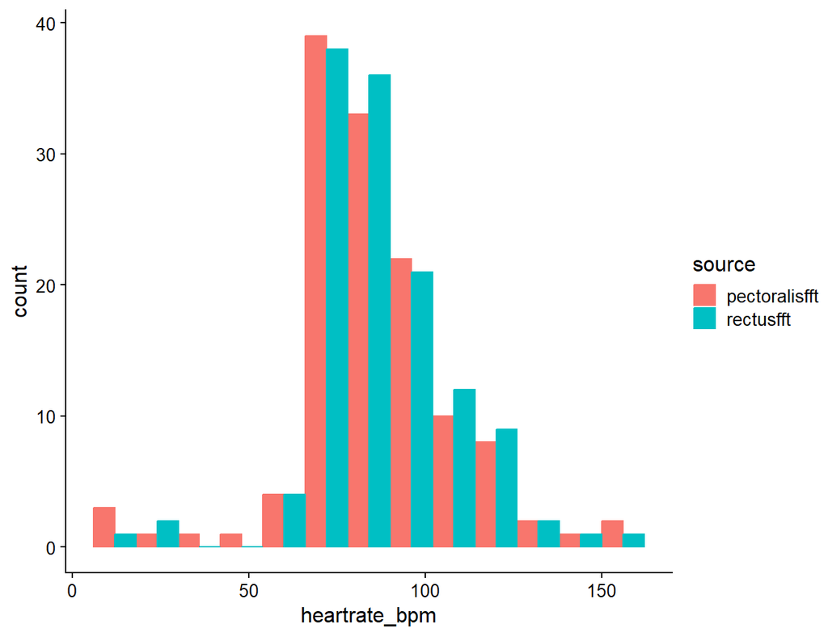

Figure 14: Plot showing the heartrates (in bpm) for EMG measures at pectoralis major and rectus abdominis. Count refers to number of trials in a certain bin.

```r
#first filter out the expire cases (they should be gone anyways)
 tr_wd_nomov <- tr_wd_nomov %>%
   dplyr::filter(vocal_condition == 'expire')

#create new dataset for plotting
heartrate <- tr_wd_nomov %>%
  dplyr::select(c(heartrate_pectoralisfft_hz, heartrate_rectusfft_hz)) %>%
  tidyr::gather(key = source, value = heartrate_hz, heartrate_pectoralisfft_hz, heartrate_rectusfft_hz) %>%
  mutate(source = gsub("heartrate_|_hz", "", source))

heartrate <- heartrate %>%
  mutate(heartrate_bpm = heartrate_hz * 60)

heartrateplot <- heartrate %>%
  ggplot(aes(x=heartrate_bpm, fill = source, color = source)) +
  geom_histogram(position="dodge", binwidth = 12)+
  # scale_fill_manual(values = c('#e7298a', '#d95f02')) +
  # scale_color_manual(values = c('#e7298a', '#d95f02')) +
  theme(legend.position="top") +
  theme_cowplot(12)

#also create the new EMG column in nomovement, so that rectus is taken from participant 9, otherwise all are pectoralis
nomovement <- nomovement %>%
  mutate(EMG = ifelse(pp == 9, rectus_abdominis, pectoralis_major))
```

# Supporting results

## Is there coherence between heart rate and vocalization?

To test this question, we compute coherence between the pectoralis major EMG signal and amplitude envelope time series. We do this for real pairs, i.e. both time series are from the same trial, and false pairs, i.e. the two signals are randomly combined across trials.

The false pairs are created by using base R’s sample(), which creates a shuffled, random vector of the trials. It is supported by a safety net function that makes sure that no trial in the original and the new vector are the same and that no false pair consists of trials from the same participant. Setting replace to FALSE ensures that no trial occurs twice in the shuffled version.

Coherence is then computed for each trial between the detrended amplitude envelope and the pectoralis major EMG signal for real and false pairs via seewave::coh().

**Show code for coherence analysis**

```r
### create real and false pairs
# real pairs: use trial pairings as recorded
# false pairs: take tr_wd_nomov$uniquetrials and randomly combine them

tr_wd_nomov <- tr_wd_nomov %>%
  mutate(pptrial = stringr::str_replace(uniquetrial, "(\\d+)_+(\\d+)", "\\2_\\1"))

#real pairs df:
realpairs <- nomovement %>%
  select(c(time_ms, env_z_detrend, rectus_abdominis, pectoralis_major, EMG, pptrial))

realpairs <- realpairs %>%
  group_by(pptrial) %>%
  slice_head(n=12496) %>%
  ungroup()


#false pairs df:
#create function to shuffle vector until no element matches its corresponding element in the original vector
#the second part of the while loop also makes sure that no trials from the same participant are matched

shuffle_until_no_matches <- function(original) {
  shuffled <- sample(original, replace = FALSE)
  while (any(shuffled == original) || any(sapply(strsplit(shuffled, "_"), `[`, 1) == sapply(strsplit(original, "_"), `[`, 1))) {
    shuffled <- sample(original, replace = FALSE)
  }
  return(shuffled)
}
#set seed for reproducibility; change this to re-shuffle
set.seed(1234)
tr_wd_nomov$pptrial_shuffled <- shuffle_until_no_matches(tr_wd_nomov$pptrial)

#now make a dataset with false pairs
falsepairs <- data.frame()
for(ID in tr_wd_nomov$pptrial)
{
  if(!(ID %in% unique(nomovement$pptrial)))
  {
    print(paste0("ID ", ID, " not found in nomovement dataset"))
  }
  if(ID %in% unique(nomovement$pptrial)) # CHECK!!!
  {
  shuffleID <- tr_wd_nomov$pptrial_shuffled[tr_wd_nomov$pptrial==ID]
  if(shuffleID %in% unique(nomovement$pptrial))
  {
  #for all time series there are either 12,497 (n=73) or 12,498 (n=55) data points, so we'll shorten them all to 12,496 (so it is divisible by 2 for later analysis of first and second half)
  #pick time & and envelope from the ID part
  time_ms <- nomovement %>%
    dplyr::filter(pptrial == ID) %>%
    select(time_ms) %>%
    slice_head(n=12496)

  #pick the envelope from ID
  env_z_detrend <- nomovement %>%
    dplyr::filter(pptrial == ID) %>%
    select(env_z_detrend) %>%
    slice_head(n=12496)

  #pick the EMG signals from the randomly assigned shuffleID
  rectus_abdominis <- nomovement %>%
    dplyr::filter(pptrial == shuffleID) %>%
    select(rectus_abdominis) %>%
    slice_head(n=12496)

  pectoralis_major <- nomovement %>%
    dplyr::filter(pptrial == shuffleID) %>%
    select(pectoralis_major) %>%
    slice_head(n=12496)

  EMG <- nomovement %>%
    dplyr::filter(pptrial == shuffleID) %>%
    select(EMG) %>%
    slice_head(n=12496)

  falsepairs_temp <- cbind.data.frame(time_ms, env_z_detrend, rectus_abdominis, pectoralis_major, EMG, ID, shuffleID)
  falsepairs <- rbind(falsepairs, falsepairs_temp)
    }
  }
}
```

```
[1] "ID 11_83 not found in nomovement dataset"
[1] "ID 11_88 not found in nomovement dataset"
```

**Show code for coherence analysis**

```r
#rename 2 columns in falsepairs for uniformity across datasets
falsepairs <- falsepairs %>%
  dplyr::rename(pptrial = ID)
falsepairs <- falsepairs %>%
  dplyr::rename(pptrial_shuffle = shuffleID)
```

Now we use these two newly created data frames to compute coherence for false and real pairs.

**Show code for coherence analysis**

```r
### compute coherence
#start with realpairs
coherence_realpairs <- realpairs %>%
  group_by(pptrial) %>%
  reframe(coh = coh(env_z_detrend, EMG, f = 2500, plot = F))

#convert from kHz to Hz
coherence_realpairs$frequency <- coherence_realpairs$coh[,1] * 1000
coherence_realpairs$coherence <- coherence_realpairs$coh[,2]
coherence_realpairs <- coherence_realpairs %>%
    select(!coh)


#do the same for falsepairs
coherence_falsepairs <- falsepairs %>%
  group_by(pptrial) %>%
  reframe(coh = coh(env_z_detrend, EMG, f = 2500, plot = F))

#convert from kHz to Hz
coherence_falsepairs$frequency <- coherence_falsepairs$coh[,1] * 1000
coherence_falsepairs$coherence <- coherence_falsepairs$coh[,2]
coherence_falsepairs <- coherence_falsepairs %>%
    select(!coh)
```

Next, we plot coherence for real and false pairs (see Fig. 15). In the plots separated by trial, we inserted a vertical line that represents the heart rate that we extracted from the FFTs of the EMG signal.

**Show code for coherence analysis**

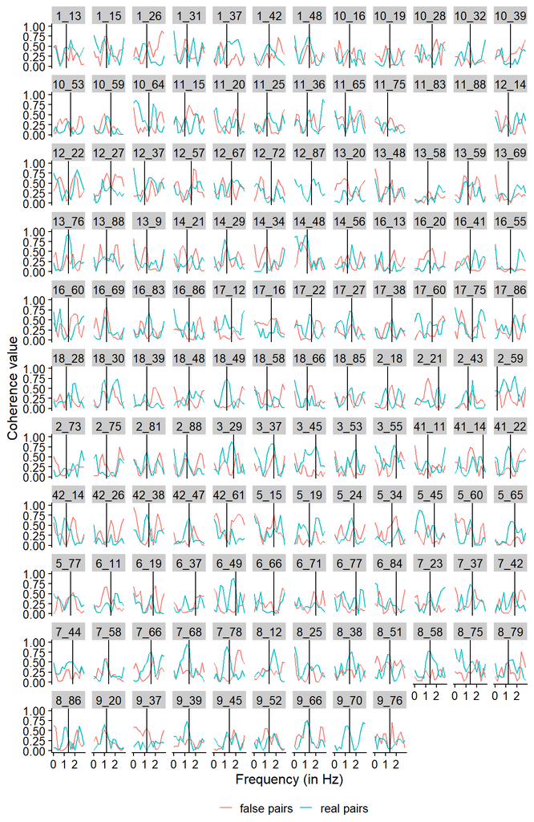

Figure 15: Plot showing the coherence spectra for real (turquoise) and false pairs (red) between detrended amplitude envelope and EMG signal. The vertical line inserted expresses the heartrate extracted from the FFT of the EMG signal in that particular trial.

```r
#now plot coherence for real & fake pairs for 0-3 Hz
#create participant column from pptrial
coherence_realpairs$participant <- sub("_(.*)", "", coherence_realpairs$pptrial)
coherence_falsepairs$participant <- sub("_(.*)", "", coherence_falsepairs$pptrial)
coherence_realpairs$pair <- "real_pair"
coherence_falsepairs$pair <- "false_pair"
coherence_pairs <- rbind(coherence_realpairs, coherence_falsepairs)
coherence_pairs <- coherence_pairs %>%
  mutate(id_pair = paste0(pptrial, "_", pair))

heartrateline <- data.frame(pptrial = tr_wd_nomov$pptrial, heartrate = tr_wd_nomov$heartrate_EMG_hz)
heartrateline$participant <- sub("_(.*)", "", heartrateline$pptrial)


coherence_pairs_plot <- coherence_pairs %>%
  dplyr::filter(frequency <= 3) %>%
  ggplot(aes(x=frequency, group = id_pair, color = pair)) +
  geom_path(aes(y=coherence)) +
  theme_cowplot(12) +
  theme(legend.position = "none") +
  facet_wrap(~pptrial) +
  ylab("Coherence value") +
  xlab("Frequency (in Hz)") +
  ylim(0, 1) +
  geom_vline(data = heartrateline, aes(xintercept = heartrate), color = "black") +
  scale_color_discrete(labels = c("false pairs", "real pairs")) +
  scale_fill_discrete(labels = c("false pairs", "real pairs")) +
  theme(legend.position = "bottom", legend.box = "horizontal", legend.justification = "center",
        legend.title = element_blank())

# coherence_realpairs_plot <- coherence_realpairs %>%
#   dplyr::filter(frequency <= 3) %>%
#   ggplot(aes(x=frequency, group = pptrial, color = participant)) +
#   geom_path(aes(y=coherence)) +
#   theme_cowplot(12) +
#   theme(legend.position = "none") +
#   facet_wrap(~pptrial) +
#   ylab("Coherence value") +
#   xlab("Frequency (in Hz)") +
#   ylim(0, 1) +
#   geom_vline(data = heartrateline, aes(xintercept = heartrate, color = participant))
#
# coherence_falsepairs_plot <- coherence_falsepairs %>%
#   dplyr::filter(frequency <= 3) %>%
#   ggplot(aes(x=frequency, group = pptrial, color = participant)) +
#   geom_path(aes(y=coherence)) +
#   theme_cowplot(12) +
#   theme(legend.position = "none") +
#   facet_wrap(~pptrial) +
#   ylab("Coherence value") +
#   xlab("Frequency (in Hz)") +
#   ylim(0, 1) +
#   geom_vline(data = heartrateline, aes(xintercept = heartrate, color = participant))
```

We extract the coherence value at the point where the vertical lines were drawn in the plot for visualization (or rather at the closest frequency value in the coherence data, as the data is not continuous). That gives us the coherence value at the frequency of heart rate in a given trial.

**Show code for extracting coherence at frequency of heart rate**

```r
#now extract the coherence values at the point of heartrate
heartrate_coh <- data.frame()
heartrate_coh_temp <- data.frame()

#at frequency of heart rate, extract the coherence value
#since there is no value at the exact frequency, we choose the closest one
for(ID in tr_wd_nomov$pptrial)
{
  if(ID %in% unique(tr_wd_nomov$pptrial))
  {
  heartrate_hz <- tr_wd_nomov$heartrate_EMG_hz[tr_wd_nomov$pptrial==ID]
  if(!is.na(heartrate_hz))
  {
  coherence_realpairs_temp <- coherence_realpairs %>%
    dplyr::filter(pptrial == ID)
  closest_index <- which.min(abs(coherence_realpairs_temp$frequency - heartrate_hz))
  closest_frequency <- coherence_realpairs_temp$frequency[closest_index]
  coherence <- coherence_realpairs_temp$coherence[closest_index]

  heartrate_coh_temp <- cbind.data.frame(heartrate_hz, closest_index, closest_frequency, coherence, ID)
  heartrate_coh <- rbind(heartrate_coh, heartrate_coh_temp)
  }
  }
}

#do the same for false pairs (CHECK!! WIM)
heartrate_coh_false <- data.frame()
heartrate_coh_temp_false <- data.frame()

for(ID in tr_wd_nomov$pptrial)
{
  if(ID %in% unique(tr_wd_nomov$pptrial))
  {
  heartrate_hz <- tr_wd_nomov$heartrate_EMG_hz[tr_wd_nomov$pptrial==ID]
  if(!is.na(heartrate_hz))
  {
  coherence_falsepairs_temp <- coherence_falsepairs %>%
    dplyr::filter(pptrial == ID)
  closest_index <- which.min(abs(coherence_falsepairs_temp$frequency - heartrate_hz))
  closest_frequency <- coherence_falsepairs_temp$frequency[closest_index]
  coherence <- coherence_falsepairs_temp$coherence[closest_index]

  if(!length(closest_index)==0)
  {

  heartrate_coh_temp_false <- cbind.data.frame(heartrate_hz, closest_index, closest_frequency, coherence, ID)
  heartrate_coh_false <- rbind(heartrate_coh_false, heartrate_coh_temp_false)
  }
  }
  }
}
```

Now that we have those coherence values, we can plot them and test if there is a difference in coherence values for real and false pairs. Fig. 16 shows the difference in coherence values for false and right pairs.

**Show code creating the boxplot**

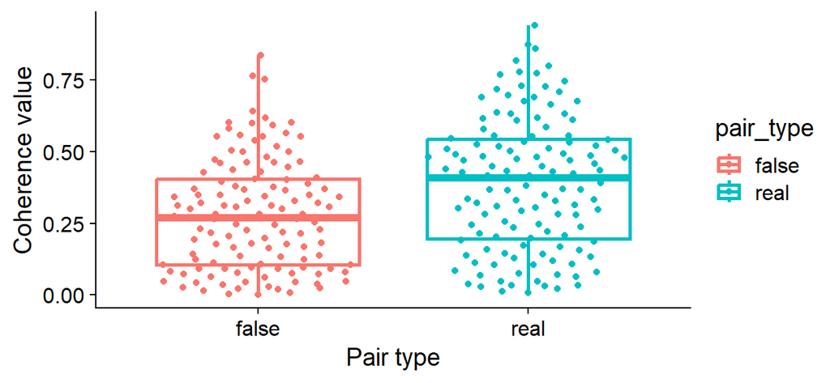

Figure 16: Box plot showing the coherence values for false (left) and real (pairs) pairs.

```r
#first we merge the two dataframes for plotting & modeling
heartrate_coh_false <- mutate(heartrate_coh_false, pair_type = "false")
heartrate_coh <- mutate(heartrate_coh, pair_type = "real")
heartrate_coherence <- rbind(heartrate_coh, heartrate_coh_false)

coherence_realfalsepairs_plot <- ggplot(heartrate_coherence, aes(x = pair_type, y = coherence, color = pair_type)) +
  geom_boxplot(size = 1) +
  geom_quasirandom() +
  theme_bw() +
  ylab('Coherence value') +
  xlab('Pair type') +
  theme_cowplot()
```

**Show code modeling coherence in real and false pairs**

```r
#reorder the coherence pair type levels, so that false becomes the intercept
heartrate_coherence$pair_type <- factor(heartrate_coherence$pair_type, levels=c('false', 'real'))

#model the data, compare to null model
model_realfalse_coherence_null <- lmer(coherence ~ 1 + (1 |ID), data = heartrate_coherence)
model_realfalse_coherence <- lmer(coherence ~ pair_type + 1 + (1|ID), data = heartrate_coherence)
comparison_realfalse_coherence <- anova(model_realfalse_coherence_null, model_realfalse_coherence)

#also save the model output in a data frame
modelsummary_realfalse_coherence <- summary(model_realfalse_coherence)$coefficients
colnames(modelsummary_realfalse_coherence) <- c('Estimate', 'SE', 'df', 't-value', 'p-value')
rownames(modelsummary_realfalse_coherence) <- c('Intercept (false pairs)', 'vs. real pairs')
```

With a mixed linear regression we modeled the variation in coherence (using R-package lme4), with trial as random intercept (for more complex random slope models did not converge). A model with pairing type (real vs false pairs) explained more variance than a base model predicting the overall mean, Change in Chi-Squared (1.00) = 16.16, *p* < .001.

Model coefficients are shown in Table S1. We find that real pairs (as opposed to the false pairs, i.e. the intercept ) had higher coherence values for the heart rate frequency.

Table 1: Table 2: Effects of pairing type on coherence values.

|  | Estimate | SE | df | t-value | p-value |
| --- | --- | --- | --- | --- | --- |
| Intercept (false pairs) | 0.281 | 0.019 | 249.550 | 14.755 | 0.000 |
| vs. real pairs | 0.108 | 0.026 | 126.030 | 4.125 | 0.000 |

**Show code setting up Granger causality test**

```r
#first run it with with envelope predicted by EMG
granger <- data.frame()
granger_temp <- data.frame()

for(ID in tr_wd_nomov$pptrial)
{
  if(!(ID %in% unique(nomovement$pptrial)))
  {
    print(paste0("ID ", ID, " not found in nomovement dataset"))
  }
  if(ID %in% unique(nomovement$pptrial)) # CHECK!!!
  {
  granger_temp <- realpairs %>%
    dplyr::filter(pptrial == ID) %>%
    grangertest(env_z_detrend ~ EMG, order = 1, data = .)

  granger_temp$pptrial <- ID

  granger <- rbind(granger, granger_temp[2, ])
  }
}
```

```
[1] "ID 11_83 not found in nomovement dataset"
[1] "ID 11_88 not found in nomovement dataset"
```

**Show code setting up Granger causality test**

```r
#now do the same but switch envelope and EMG signal around
granger_reverse <- data.frame()
granger_reverse_temp <- data.frame()

for(ID in tr_wd_nomov$pptrial)
{
  if (!(ID %in% unique(nomovement$pptrial)))
  {
    print(paste0("ID ", ID, " not found in nomovement dataset"))
  }
  if (ID %in% unique(nomovement$pptrial)) # CHECK!!!
  {
  granger_reverse_temp <- realpairs %>%
    dplyr::filter(pptrial == ID) %>%
    grangertest(EMG ~ env_z_detrend, order = 1, data = .)

  granger_reverse_temp$pptrial <- ID

  granger_reverse <- rbind(granger_reverse, granger_reverse_temp[2, ])
  }
}
```

```
[1] "ID 11_83 not found in nomovement dataset"
[1] "ID 11_88 not found in nomovement dataset"
```

## Is the heart rate effect on the voice stronger at the beginning of vocalizations?

To test this question, we split the trials into first half and second half. The first half include data from 1001 to 3500 ms, the second half from 3500 to 5999 ms. Then we compute coherence between the amplitude envelope and EMG signal (real pairs only here). Finally, we compare if coherence is higher in the first half when compared to the second half. For reference, we also include false and real pairs for the first and second half again. Therefore we have four data sets here (first vs second half, and real vs false pairs).

**Show code for coherence in split time series**

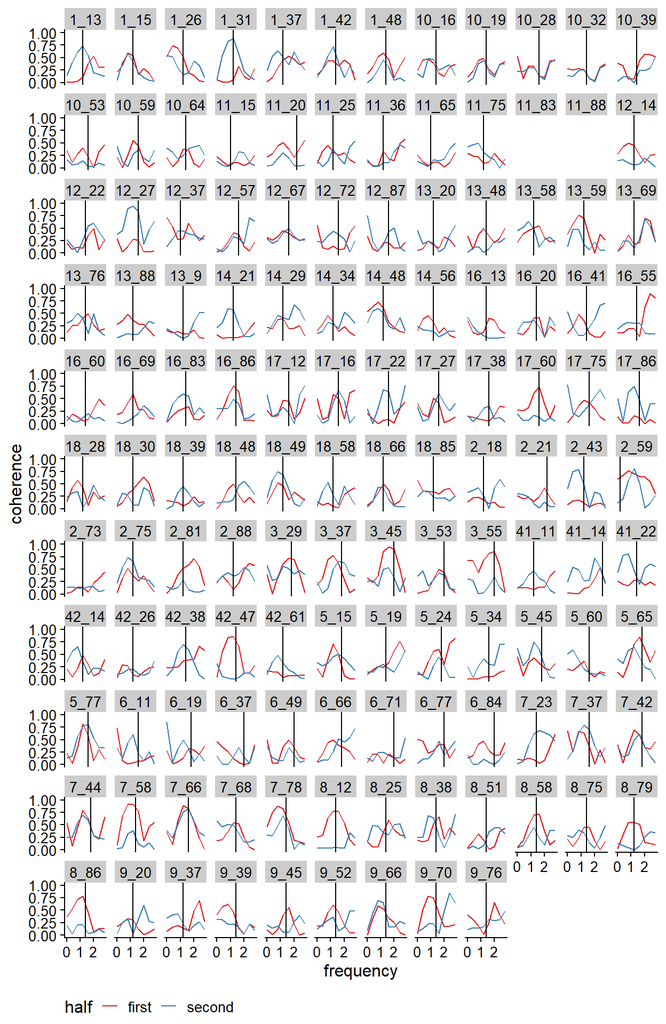

Figure 17: Coherence spectra for first (red) and second (blue) half of the time in real pairs.

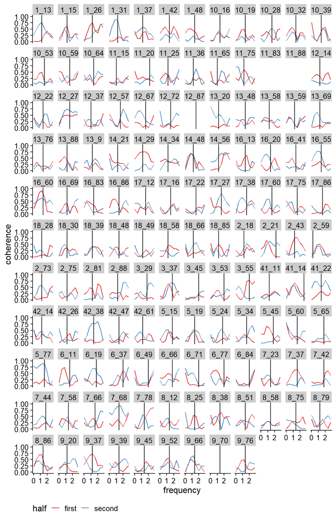

Figure 18: Coherence spectra for first (red) and second (blue) half of the time in false pairs

```r
#we will here use realpairs and falsepairs from above, which are already shortened to 12,496 data points
#first we separate into 1st and 2nd half; this creates 4 dataframes (2 pair types, 2 halves)
firsthalf_real <- realpairs %>%
  group_by(pptrial) %>%
  slice_head(n = 12496 / 2)

firsthalf_false <- falsepairs %>%
  group_by(pptrial) %>%
  slice_head(n = 12496 / 2)

secondhalf_real <- realpairs %>%
  group_by(pptrial) %>%
  slice_tail(n = 12496 / 2)

secondhalf_false <- falsepairs %>%
  group_by(pptrial) %>%
  slice_tail(n = 12496 / 2)

#the two firsthalf dfs now include time from 1001 to 3500 ms
#the two secondhalf dfs now include time from 3500 to 5999 ms

#include false pairings here; we just add the false pair EMG signal to the existing dataset
# firsthalf_full <- data.frame()
# secondhalf_full <- data.frame()
# for(ID in tr_wd_nomov$pptrial)
# {
#   shuffleID <- tr_wd_nomov$pptrial_shuffled[tr_wd_nomov$pptrial==ID]
#
#   EMG_firsthalf_false <- firsthalf %>%
#     dplyr::filter(pptrial == shuffleID) %>%
#     select(time_ms, pectoralis_major)
#   EMG_firsthalf_false$shuffleID <- shuffleID
#   EMG_firsthalf_false$pptrial <- ID
#
#   EMG_firsthalf_false <- EMG_firsthalf_false %>%
#     rename(pectoralis_major_false = pectoralis_major)
#
#    firsthalf_temp <- firsthalf %>%
#     dplyr::filter(pptrial == ID)
#   firsthalf_temp <- left_join(firsthalf_temp, EMG_firsthalf_false, by = c("pptrial" = "pptrial", "time_ms" = "time_ms"))
#   firsthalf_full <- rbind(firsthalf_full, firsthalf_temp)
#
#   #do the same for second half
#   EMG_secondhalf_false <- secondhalf %>%
#     dplyr::filter(pptrial == shuffleID) %>%
#     select(time_ms, pectoralis_major)
#   EMG_secondhalf_false$shuffleID <- shuffleID
#   EMG_secondhalf_false$pptrial <- ID
#
#   EMG_secondhalf_false <- EMG_secondhalf_false %>%
#     rename(pectoralis_major_false = pectoralis_major)
#
#   secondhalf_temp <- secondhalf %>%
#     dplyr::filter(pptrial == ID)
#   secondhalf_temp <- left_join(secondhalf_temp, EMG_secondhalf_false, by = c("pptrial" = "pptrial", "time_ms" = "time_ms"))
#   secondhalf_full <- rbind(secondhalf_full, secondhalf_temp)
#   }


#compute coherence for first and second half of the trials
#first for firsthalf
#make sure there are no NAs in there
# firsthalf_full <- firsthalf_full %>%
#     tidyr::drop_na(pectoralis_major_false)

coherence_firsthalf_real <- firsthalf_real %>%
  group_by(pptrial) %>%
  reframe(coh = coh(env_z_detrend, EMG, f = 2500, plot = F))

#convert from kHz to Hz
coherence_firsthalf_real$frequency <- coherence_firsthalf_real$coh[,1] * 1000
coherence_firsthalf_real$coherence <- coherence_firsthalf_real$coh[,2]
coherence_firsthalf_real <- coherence_firsthalf_real %>%
    select(!coh)
coherence_firsthalf_real <- coherence_firsthalf_real %>%
  mutate(pair_type = "real")

#add false pairs to it
coherence_firsthalf_false <- firsthalf_false %>%
  group_by(pptrial) %>%
  reframe(coh = coh(env_z_detrend, EMG, f = 2500, plot = F))

coherence_firsthalf_false$frequency <- coherence_firsthalf_false$coh[,1] * 1000
coherence_firsthalf_false$coherence <- coherence_firsthalf_false$coh[,2]
coherence_firsthalf_false <- coherence_firsthalf_false %>%
    select(!coh)
coherence_firsthalf_false <- coherence_firsthalf_false %>%
  mutate(pair_type = "false")

coherence_firsthalf <- rbind(coherence_firsthalf_real, coherence_firsthalf_false)

### same for second half
coherence_secondhalf_real <- secondhalf_real %>%
  group_by(pptrial) %>%
  reframe(coh = coh(env_z_detrend, EMG, f = 2500, plot = F))

#convert from kHz to Hz
coherence_secondhalf_real$frequency <- coherence_secondhalf_real$coh[,1] * 1000
coherence_secondhalf_real$coherence <- coherence_secondhalf_real$coh[,2]
coherence_secondhalf_real <- coherence_secondhalf_real %>%
    select(!coh)
coherence_secondhalf_real <- coherence_secondhalf_real %>%
  mutate(pair_type = "real")

#add false pairs to it
coherence_secondhalf_false <- secondhalf_false %>%
  group_by(pptrial) %>%
  reframe(coh = coh(env_z_detrend, EMG, f = 2500, plot = F))

#convert from kHz to Hz
coherence_secondhalf_false$frequency <- coherence_secondhalf_false$coh[,1] * 1000
coherence_secondhalf_false$coherence <- coherence_secondhalf_false$coh[,2]
coherence_secondhalf_false <- coherence_secondhalf_false %>%
    select(!coh)
coherence_secondhalf_false <- coherence_secondhalf_false %>%
  mutate(pair_type = "false")

coherence_secondhalf <- rbind(coherence_secondhalf_real, coherence_secondhalf_false)

#put them into the same dataframe
coherence_firsthalf <- mutate(coherence_firsthalf, half = "first")
coherence_secondhalf <- mutate(coherence_secondhalf, half = "second")
halves_coherence <- rbind(coherence_firsthalf, coherence_secondhalf)
#create combination of pptrial and half for grouping in plot
halves_coherence <- halves_coherence %>%
  mutate(pptrialhalftype = paste0(pptrial, "_", half, "_", pair_type))

halves_coherence <- halves_coherence %>%
  mutate(type = paste0(half, "_", pair_type))
#create plot
#heartrateline <- data.frame(pptrial = tr_wd_nomov$pptrial, heartrate = tr_wd_nomov$heartrate_pectoralisfft_hz)

coherence_halves_plot_real <- halves_coherence %>%
  dplyr::filter(frequency <= 3) %>%
  dplyr::filter(pair_type == "real") %>%
  ggplot(aes(x=frequency)) +
  geom_path(aes(y=coherence, group = pptrialhalftype, color = half)) +
  theme_cowplot(12) +
  theme(legend.position = "bottom") +
  facet_wrap(~pptrial) +
  ylim(0, 1) +
  geom_vline(data = heartrateline, aes(xintercept = heartrate)) +
  scale_colour_brewer(palette = "Set1")

coherence_halves_plot_false <- halves_coherence %>%
  dplyr::filter(frequency <= 3) %>%
  dplyr::filter(pair_type == "false") %>%
  ggplot(aes(x=frequency)) +
  geom_path(aes(y=coherence, group = pptrialhalftype, color = half)) +
  theme_cowplot(12) +
  theme(legend.position = "bottom") +
  facet_wrap(~pptrial) +
  ylim(0, 1) +
  geom_vline(data = heartrateline, aes(xintercept = heartrate)) +
  scale_colour_brewer(palette = "Set1")
```

**Show code comparing coherence between the two halves**

```r
#compare coherence between the 2 halves; and for real vs false pairs
#get coherence value at frequency of heart rate
#start with first half
firsthalf_real_coh_temp <- data.frame()
firsthalf_real_coh <- data.frame()

#at frequency of heart rate, extract the coherence value
#since there is no value at the exact frequency, we choose the closest one
for(ID in tr_wd_nomov$pptrial)
{
  if(!(ID %in% unique(tr_wd_nomov$pptrial)))
  {
    print(paste0("ID ", ID, " not found in nomovement dataset"))
  }
  if (ID %in% unique(tr_wd_nomov$pptrial)) # CHECK!!!
  {
  heartrate_hz <- tr_wd_nomov$heartrate_EMG_hz[tr_wd_nomov$pptrial==ID]
  coherence_firsthalf_real_temp <- coherence_firsthalf_real %>%
    dplyr::filter(pptrial == ID)
  closest_index <- which.min(abs(coherence_firsthalf_real_temp$frequency - heartrate_hz))
  closest_frequency <- coherence_firsthalf_real_temp$frequency[closest_index]
  coherence <- coherence_firsthalf_real_temp$coherence[closest_index]
  if (!length(closest_index)==0)
  {
  firsthalf_real_coh_temp <- cbind.data.frame(heartrate_hz, closest_index, closest_frequency, coherence, ID)
  firsthalf_real_coh <- rbind(firsthalf_real_coh, firsthalf_real_coh_temp)
  }
  }
}

#now for false pairs in firsthalf
firsthalf_false_coh_temp <- data.frame()
firsthalf_false_coh <- data.frame()

for(ID in tr_wd_nomov$pptrial)
{
  if (!(ID %in% unique(tr_wd_nomov$pptrial)))
  {
    print(paste0("ID ", ID, " not found in nomovement dataset"))
  }
  if (ID %in% unique(tr_wd_nomov$pptrial)) # CHECK!!!
  {
  heartrate_hz <- tr_wd_nomov$heartrate_EMG_hz[tr_wd_nomov$pptrial==ID]
  coherence_firsthalf_false_temp <- coherence_firsthalf_false %>%
    dplyr::filter(pptrial == ID)
  closest_index <- which.min(abs(coherence_firsthalf_false_temp$frequency - heartrate_hz))
  closest_frequency <- coherence_firsthalf_false_temp$frequency[closest_index]
  coherence <- coherence_firsthalf_false_temp$coherence[closest_index]
  if (!length(closest_index)==0)
  {

  firsthalf_false_coh_temp <- cbind.data.frame(heartrate_hz, closest_index, closest_frequency, coherence, ID)
  firsthalf_false_coh <- rbind(firsthalf_false_coh, firsthalf_false_coh_temp)
  }
  }
}


### then same for second half
secondhalf_real_coh_temp <- data.frame()
secondhalf_real_coh <- data.frame()

#at frequency of heartrate, extract the coherence value
#since there is no value at the exact frequency, we choose the closest one
for(ID in tr_wd_nomov$pptrial)
{
  if(!(ID %in% unique(tr_wd_nomov$pptrial)))
  {
    print(paste0("ID ", ID, " not found in nomovement dataset"))
  }
  if (ID %in% unique(tr_wd_nomov$pptrial)) # CHECK!!!
  {
  heartrate_hz <- tr_wd_nomov$heartrate_EMG_hz[tr_wd_nomov$pptrial==ID]
  coherence_secondhalf_real_temp <- coherence_secondhalf_real %>%
    dplyr::filter(pptrial == ID)
  closest_index <- which.min(abs(coherence_secondhalf_real_temp$frequency - heartrate_hz))
  closest_frequency <- coherence_secondhalf_real_temp$frequency[closest_index]
  coherence <- coherence_secondhalf_real_temp$coherence[closest_index]
  }
  if (!length(closest_index)==0)
  {
  secondhalf_real_coh_temp <- cbind.data.frame(heartrate_hz, closest_index, closest_frequency, coherence, ID)
  secondhalf_real_coh <- rbind(secondhalf_real_coh, secondhalf_real_coh_temp)
  }
}

#now for false pairs in secondhalf
secondhalf_false_coh_temp <- data.frame()
secondhalf_false_coh <- data.frame()

for(ID in tr_wd_nomov$pptrial)
{
  if (!(ID %in% unique(tr_wd_nomov$pptrial)))
  {
    print(paste0("ID ", ID, " not found in nomovement dataset"))
  }
  if (ID %in% unique(tr_wd_nomov$pptrial)) # CHECK!!!
  {
  heartrate_hz <- tr_wd_nomov$heartrate_EMG_hz[tr_wd_nomov$pptrial==ID]
  coherence_secondhalf_false_temp <- coherence_secondhalf_false %>%
    dplyr::filter(pptrial == ID)
  closest_index <- which.min(abs(coherence_secondhalf_false_temp$frequency - heartrate_hz))
  closest_frequency <- coherence_secondhalf_false_temp$frequency[closest_index]
  coherence <- coherence_secondhalf_false_temp$coherence[closest_index]
  }
  if (!length(closest_index)==0)
  {
  secondhalf_false_coh_temp <- cbind.data.frame(heartrate_hz, closest_index, closest_frequency, coherence, ID)
  secondhalf_false_coh <- rbind(secondhalf_false_coh, secondhalf_false_coh_temp)
  }
}
```

Now that we have the coherence values, we can plot (see Fig. 19) and model the potential difference.

**Show code creating the boxplot**

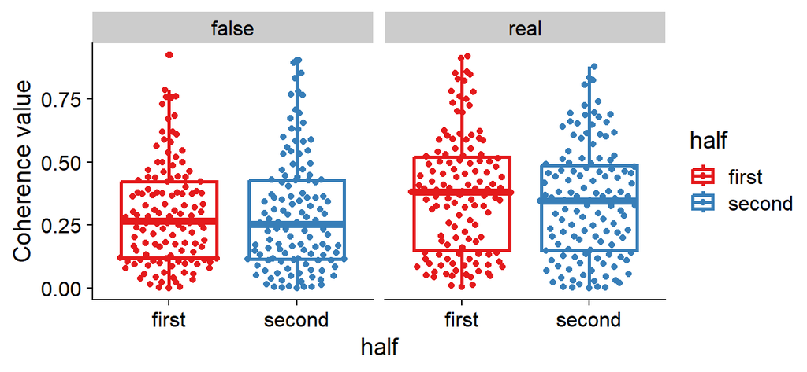

Figure 19: Box plot showing the coherence values for first and second half pairs. The plot is also facetted by real and false pairs.

```r
#first we merge the dataframes for plotting & modeling
firsthalf_real_coh <- mutate(firsthalf_real_coh, half = "first", pair_type = "real")
firsthalf_false_coh <- mutate(firsthalf_false_coh, half = "first", pair_type = "false")
secondhalf_real_coh <- mutate(secondhalf_real_coh, half = "second", pair_type = "real")
secondhalf_false_coh <- mutate(secondhalf_false_coh, half = "second", pair_type = "false")

firstsecondhalf_coherence <- rbind(firsthalf_real_coh,
                                   firsthalf_false_coh,
                                   secondhalf_real_coh,
                                   secondhalf_false_coh)

coherence_firstsecondhalf_plot <- ggplot(firstsecondhalf_coherence, aes(x = half, y = coherence, color = half)) +
  geom_boxplot(size = 1) +
  geom_quasirandom() +
  ylab('Coherence value') +
  scale_colour_brewer(palette = "Set1") +
  theme_cowplot() +
  facet_wrap(~pair_type)
```

## Is coherence related to heart rate?

For this question, we first compute the heart rate from the EMG signal for each trial via Fast Fourier Transform (FFT) and convert it to the more usual beats per minute (bpm).

Before the model is computed between heart rate and coherence for vocalization and EMG signal, a plot (see Fig. 20) visualizes their relationship.

**Show code relating coherence to heart rate**

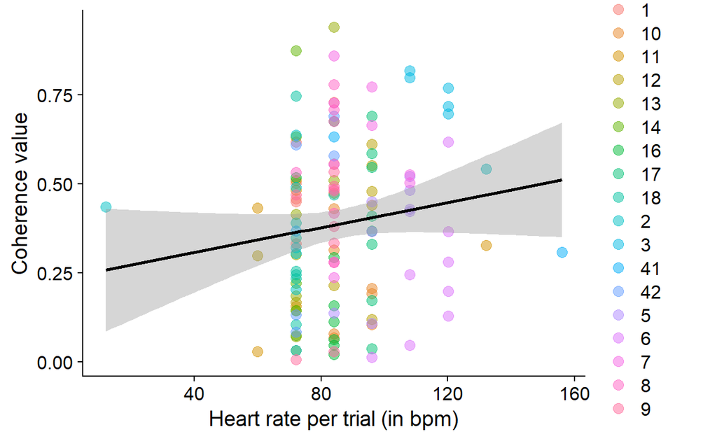

Figure 20: Plot showing the correlation between the heart rate by trial in bpm (on x-axis) and coherence values ranging from 0 to 1 (on y-axis). Color is used to show different participants.

```r
#convert heartrate from Hz to bpm
heartrate_coh <- heartrate_coh %>%
  mutate(heartrate_bpm = heartrate_hz * 60)
#create participant column from ID
heartrate_coh$participant <- sub("_(.*)", "", heartrate_coh$ID)

#plot the relationship
correlation_coherence_heartrate <- ggplot(heartrate_coh, aes(y = coherence, color = participant)) +
  geom_point(aes(x = heartrate_bpm), size = 3, alpha = 0.5) +
  geom_smooth(aes(x = heartrate_bpm), color = 'black', method = 'lm') +
  theme_bw() +
  ylab('Coherence value') +
  xlab('Heart rate per trial (in bpm)') +
  theme_cowplot()
```

We have used ID (combination of participant and trial) as a unique identifier for each trial as a random factor above. Here, this is not possible because we have less observations, so each ID only has 1 data point from heartrate or coherence respectively. Therefore, we will use participant as a random intercept.

**Show code relating coherence to heart rate**

```r
#model the data, compare to null model
model_coherence_heartrate_null <- lmer(coherence ~ 1 + (1|participant), data = heartrate_coh)
model_coherence_heartrate <- lmer(coherence ~ heartrate_bpm + (1|participant), data = heartrate_coh)
comparison_realfalse_coherence <- anova(model_coherence_heartrate_null,model_coherence_heartrate)


#also save the model output in a dataframe
modelsummary_coherence_heartrate <- summary(model_coherence_heartrate)$coefficients
colnames(modelsummary_coherence_heartrate) <- c('Estimate', 'SE', 'df', 't-value', 'p-value')
rownames(modelsummary_coherence_heartrate) <- c('Intercept', 'Effect of heartrate (in bpm)')
```

With a mixed linear regression we modeled the variation in coherence (using R-package lme4), with participant as random intercept (for more complex random slope models did not converge). A model with heart rate in bpm as predictor did not explain more variance than a base model predicting the overall mean, Change in Chi-Squared (1.00) = 2.56, *p* = 0.10988.

Model coefficients are shown in Table S3. We do not find an effect for heart rate on coherence values.

Table 3: Table 4: Effects of heartrate on coherence values.

|  | Estimate | SE | df | t-value | p-value |
| --- | --- | --- | --- | --- | --- |
| Intercept | 0.224 | 0.112 | 91.862 | 1.998 | 0.049 |
| Effect of heartrate (in bpm) | 0.002 | 0.001 | 105.575 | 1.589 | 0.115 |

## Does the onset of vocalization coincide with a heart beat?

We then locate the closest peak in the EMG signal. For this, we first locate all the peaks in the EMG signal via pracma::findpeaks(), using a minimum distance between peaks of 0.7 times the duration of one heart cycle (which we can derive from the heart rate, that we have from FFTs; e.g. if heart rate is 60 bpm or 1 Hz, duration would be 1 s) and a minimum peak height of 0, as we scaled the signals by trials. We then locate the peak closest to the velocity peak, as well as compute the distance between the two.

**Show code for testing the relation between vocalization and heartbeat**

```r
#prepare data in tsl_fulltime
tsl_fulltime <- tsl_fulltime %>%
  mutate(pptrial = stringr::str_replace(uniquetrial, "(\\d+)_+(\\d+)", "\\2_\\1"))

#transform heartrate from Hz to cycle length in s; we'll use that to determine minimum distance between peaks
tr_wd_nomov <- tr_wd_nomov %>%
  mutate(heartrate_EMG_duration = 1 / heartrate_EMG_hz)

#since we're using tsl_fulltime here, we also have to modify it, so that it uses the correct EMG signal
tsl_fulltime <- tsl_fulltime %>%
  mutate(EMG = ifelse(pp == 9, rectus_abdominis, pectoralis_major))

#set up loop for finding EMG peaks and then identifying the one closest to velocity peak
pectoralis_peaks_temp <- data.frame()
pectoralis_peaks <- data.frame()

 for(ID in tr_wd_nomov$pptrial)
 {
   if (!(ID %in% unique(nomovement$pptrial)))
   {
     print(paste0("ID ", ID, " not found in nomovement dataset"))
   }
   if (ID %in% unique(nomovement$pptrial)) # CHECK!!!
   {
   heartrate_duration <- tr_wd_nomov$heartrate_EMG_duration[tr_wd_nomov$pptrial==ID] #Note for Wim: for this, we can also use the mean distance between peaks, either via pectoralis_peaks$index (then you directly have index) or pectoralis_peaks$time
   index_duration <- 0.0004 #temporal distance between rows is 0.0004 s, as sampling rate is 2500 Hz
   heartrate_duration_indices <- heartrate_duration / index_duration

   tsl_fulltime_temp <- tsl_fulltime %>%
     dplyr::filter(pptrial == ID)

   #find peaks: we use 0.7 * duration of one heart cycle; also minpeakheight is set to 0
   pectoralis_peaks_temp <- data.frame(pracma::findpeaks(tsl_fulltime_temp$EMG, minpeakdistance = heartrate_duration_indices * 0.7, minpeakheight = 0))

   pectoralis_peaks_temp <- pectoralis_peaks_temp %>%
   dplyr::rename(height = X1,
                 index = X2,
                 onset = X3,
                 end = X4) %>%
  dplyr:: arrange(index)

  pectoralis_peaks_temp <- pectoralis_peaks_temp %>%
     mutate(time = index * index_duration)

  pectoralis_peaks_temp$velocity_peak <- tr_wd_nomov %>%
    dplyr::filter(pptrial == ID) %>%
    pull(highest_veloc_peak_time) / 1000

  #use vocalization onset; computed above via peak velocity of amplitude envelope of vocalization
   tr_wd_nomov$closest_EMG_peak_fft[tr_wd_nomov$pptrial==ID] <- pectoralis_peaks_temp$time[which.min(abs(pectoralis_peaks_temp$time - pectoralis_peaks_temp$velocity_peak))] * 1000

   pectoralis_peaks_temp$pptrial <- ID
   pectoralis_peaks <- rbind(pectoralis_peaks, pectoralis_peaks_temp)
 }
}
```

```
[1] "ID 11_83 not found in nomovement dataset"
[1] "ID 11_88 not found in nomovement dataset"
```

**Show code for testing the relation between vocalization and heartbeat**

```r
tr_wd_nomov <- tr_wd_nomov %>%
  mutate(ampEMG_peakdistance = closest_EMG_peak_fft - highest_veloc_peak_time)

### now also get the distance for false pairs
#we already have envelope velocity peaks for each trial in pectoralis_peaks$velocity_peak
#we also already have all the peaks for the EMG signals stored there
#all we have to do is use the shuffling to assign the false pair velocity peaks

#add pptrial_shuffled to tsl_fulltime
shuffleddf <- tr_wd_nomov %>%
  select(c(pptrial, pptrial_shuffled))

tsl_fulltime_merged <- merge(tsl_fulltime, shuffleddf, by = "pptrial", all.x = TRUE)

#set up loop for finding EMG peaks and then identifying the one closest to velocity peak
pectoralis_peaks_shuffled_temp <- data.frame()
pectoralis_peaks_shuffled <- data.frame()

for(shuffleID in tr_wd_nomov$pptrial_shuffled)
 {
  if (!(shuffleID %in% unique(nomovement$pptrial)))
   {
     print(paste0("ID ", shuffleID, " not found in nomovement dataset"))
  }
   if (shuffleID %in% unique(nomovement$pptrial)) # CHECK!!!
   {
   #get the corresponding ID from pptrial
   ID <- tr_wd_nomov$pptrial[tr_wd_nomov$pptrial_shuffled == shuffleID]
   #pick the heart rate_duration from the randomly assigned EMG signal
   heartrate_duration <- tr_wd_nomov$heartrate_EMG_duration[tr_wd_nomov$pptrial==shuffleID] #Note for Wim: as noted above: for this, we can also use the mean distance between peaks, either via pectoralis_peaks_shuffled$index (then you directly have index) or pectoralis_peaks$time; make sure, you pick the right one
   tr_wd_nomov$heartrate_EMG_duration_shuffled[tr_wd_nomov$pptrial_shuffled==shuffleID] <- tr_wd_nomov$heartrate_EMG_duration[tr_wd_nomov$pptrial==shuffleID]
   index_duration <- 0.0004 #temporal distance between rows is 0.0004 s, as sampling rate is 2500 Hz
   heartrate_duration_indices <- heartrate_duration / index_duration

   tsl_fulltime_temp <- tsl_fulltime_merged %>%
     dplyr::filter(pptrial == shuffleID)

   #find peaks: we use 0.7 * duration of one heart cycle; also minpeakheight is set to 0
   pectoralis_peaks_shuffled_temp <- data.frame(pracma::findpeaks(tsl_fulltime_temp$EMG, minpeakdistance = heartrate_duration_indices * 0.7, minpeakheight = 0))

   pectoralis_peaks_shuffled_temp <- pectoralis_peaks_shuffled_temp %>%
   dplyr::rename(height = X1,
                 index = X2,
                 onset = X3,
                 end = X4) %>%
  dplyr:: arrange(index)

  pectoralis_peaks_shuffled_temp <- pectoralis_peaks_shuffled_temp %>%
     mutate(time = index * index_duration)

  pectoralis_peaks_shuffled_temp$velocity_peak <- tr_wd_nomov %>%
    dplyr::filter(pptrial_shuffled == shuffleID) %>%
    pull(highest_veloc_peak_time) / 1000
    if(length(pectoralis_peaks_shuffled_temp$velocity_peak)> 0)
    {
      if (length(which.min(abs(pectoralis_peaks_shuffled_temp$time - pectoralis_peaks_shuffled_temp$velocity_peak))) > 0)
      {
  #use vocalization onset; computed above via peak velocity of amplitude envelope of vocalization
   tr_wd_nomov$closest_EMG_peak_fft_shuffled[tr_wd_nomov$pptrial_shuffled==shuffleID] <- pectoralis_peaks_shuffled_temp$time[which.min(abs(pectoralis_peaks_shuffled_temp$time - pectoralis_peaks_shuffled_temp$velocity_peak))] * 1000

#   pectoralis_peaks$velocity_peak_shuffled[pectoralis_peaks$pptrial_shuffled==ID] <- velocity_peak_shuffled
#   tr_wd_nomov$highest_veloc_peak_time_false[tr_wd_nomov$pptrial_shuffled==ID] <- velocity_peak_shuffled * 1000


   pectoralis_peaks_shuffled_temp$pptrial_shuffled <- shuffleID
   pectoralis_peaks_shuffled <- rbind(pectoralis_peaks_shuffled, pectoralis_peaks_shuffled_temp)
      }
    }
   }
}
```

```
[1] "ID 11_83 not found in nomovement dataset"
[1] "ID 11_88 not found in nomovement dataset"
```

**Show code for testing the relation between vocalization and heartbeat**

```r
#finally, compute the distance between the randomly assigned closest EMG peak and the highest velocity peak time
tr_wd_nomov <- tr_wd_nomov %>%
  mutate(ampEMG_peakdistance_shuffled = closest_EMG_peak_fft_shuffled - highest_veloc_peak_time)

#first include pptrial_shuffled here
# pectoralis_peaks <- left_join(pectoralis_peaks,
#                               select(tr_wd_nomov, pptrial, pptrial_shuffled),
#                               by = "pptrial")
#
# pectoralis_peaks$velocity_peak_shuffled <- NA
# tr_wd_nomov$closest_EMG_peak_fft_false <- NA
# tr_wd_nomov$highest_veloc_peak_time_false <- NA
# for(ID in pectoralis_peaks$pptrial_shuffled)
# {
#
#   velocity_peak_shuffled <- pectoralis_peaks$velocity_peak[pectoralis_peaks$pptrial==ID][1]
#   pectoralis_peaks$velocity_peak_shuffled[pectoralis_peaks$pptrial_shuffled==ID] <- velocity_peak_shuffled
#   tr_wd_nomov$highest_veloc_peak_time_false[tr_wd_nomov$pptrial_shuffled==ID] <- velocity_peak_shuffled * 1000
#
#   # tr_wd_nomov$velocity_peak_false[pectoralis_peaks$pptrial_shuffled==ID] <- pectoralis_peaks$velocity_peak[pectoralis_peaks$pptrial==ID][1]
#     #tr_wd_nomov$closest_EMG_peak_fft_false[tr_wd_nomov$pptrial_shuffled==ID] <-
#   # closest_EMG_peak_fft_false <- pectoralis_peaks %>%
#   #   dplyr::filter(pptrial_shuffled == ID) %>%
#   #   pukk(time)
#   #   mutate(min_diff = abs(time - velocity_peak_shuffled)) %>%
#   #   slice(which.min(min_diff)) %>%
#   #   summarise(time_milliseconds = time * 1000)
#
#   closest_EMG_peak_fft_false <- pectoralis_peaks$time[pectoralis_peaks$pptrial_shuffled==ID] [which.min(abs(pectoralis_peaks$time[pectoralis_peaks$pptrial_shuffled==ID] - pectoralis_peaks$velocity_peak_shuffled[pectoralis_peaks$pptrial_shuffled==ID]))] * 1000
#
#   tr_wd_nomov$closest_EMG_peak_fft_false[tr_wd_nomov$pptrial_shuffled == ID] <- closest_EMG_peak_fft_false
# }
#
# tr_wd_nomov <- tr_wd_nomov %>%
#   mutate(ampEMG_peakdistance_false = closest_EMG_peak_fft_false - highest_veloc_peak_time_false)
```

**Show code for visualizing the peaks**

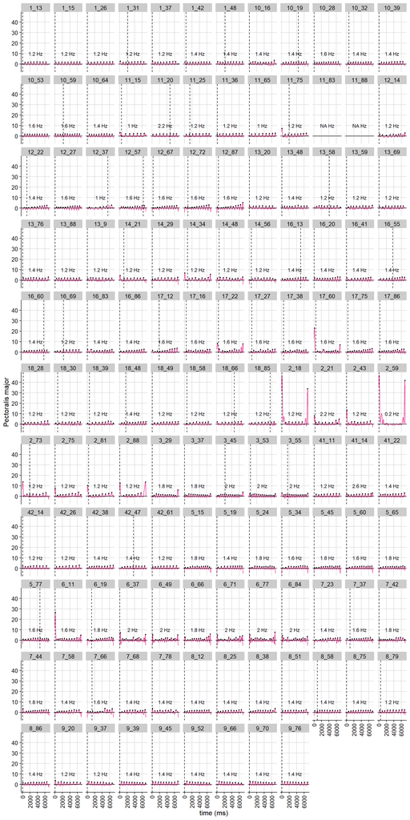

Figure 21: Plot showing the pectoralis major EMG signal with the automatically detected peaks overlaid as dots. The dashed line indicates the onset of vocalization for that particular trial.

```r
pectoralis_peaks <- pectoralis_peaks %>%
  mutate(time_ms = round(time * 1000))

allpectoralis_peaks <- ggplot() +
  geom_path(data = tsl_fulltime, aes(x=time_ms, y=EMG, color='pectoralis major')) +
  geom_point(data = pectoralis_peaks, aes(y = height, x = time_ms), color = "black", size = 0.5) +
  geom_text(data = tr_wd_nomov, aes(label = paste0(round(heartrate_EMG_hz, 2), " Hz"), x = 3500, y = 10), size = 3) +
  geom_vline(data = tr_wd_nomov, aes(xintercept = highest_veloc_peak_time), linetype = 2) + #add line about velocity peaks
  #geom_vline(data = tr_wd_nomov, aes(xintercept = highest_veloc_peak_time_false), color = "red") +
  scale_color_manual(values = colors_mus) +
  scale_y_continuous(name = "Pectoralis major", limits = c(-5, 47)) + #,limits = c(-3, 3)
  #scale_x_continuous(limits = c(0, 2000)) +
  #theme(legend.position = c(0.8, 1)) +
  geom_hline(yintercept= 0) +
  #xlim(0, 7000) +
  xlab('time (ms)') +
  theme_cowplot(12) +
  background_grid() +
  theme(legend.position = "none",
        axis.text.x = element_text(angle = 90, vjust = 0.5, hjust=1)) +
  facet_wrap(~pptrial)
```

Next, we normalize the distance by the respective duration of one heart cycle and thus transform it to degrees. We then plot the density of the respective degrees into a straight plot (see Fig. 22) where we include both negative and positive values. We also show the density distribution in a circular plot, where the values are absolutized (see Fig. 23).

**Show code for transforming the distance into phase**

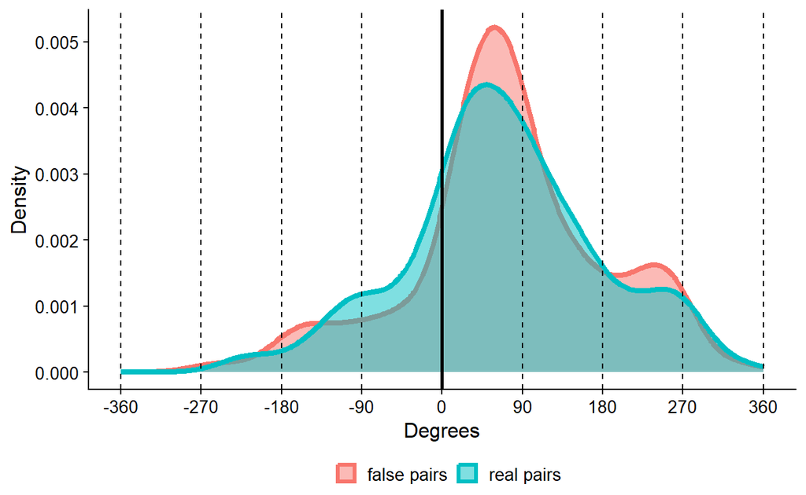

Figure 22: Density plot showing the distance distance between velocity peak and the nearest EMG peak. Distance was transformed to degrees. The solid black line indicates the velocity peak as a reference point. Blue is for real pairs and red for false pairs. The plot includes both negative (i.e. closest heart beat occurring before onset of vocalization) and positive values (i.e. closest heart beat occurring after onset of vocalization)

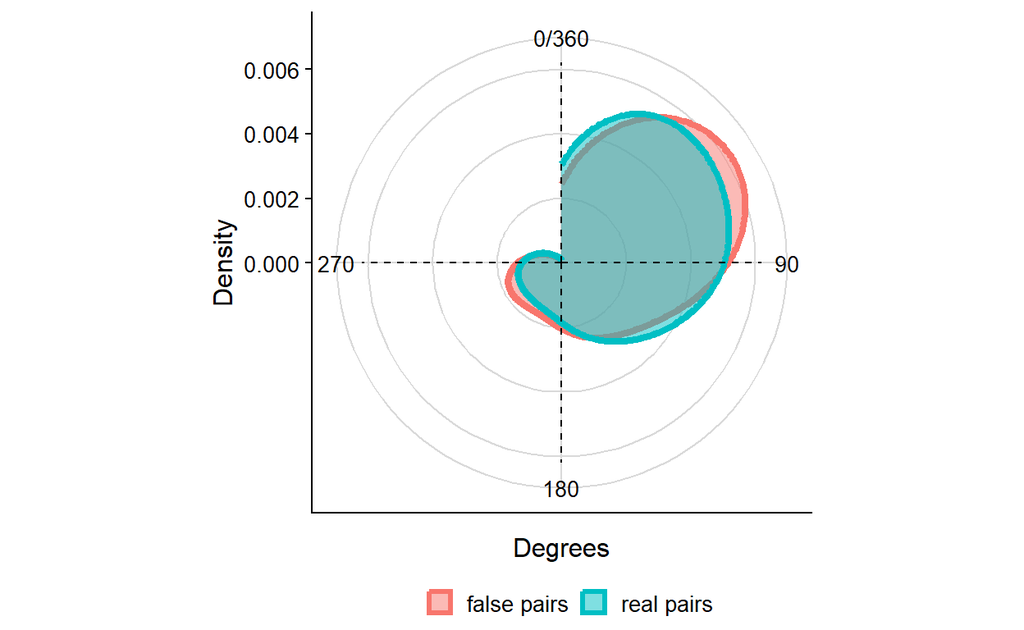

Figure 23: Density plot showing the distance distance between velocity peak and the nearest EMG peak. Distance was transformed to degrees. Values were absolutized here.

```r
tr_wd_nomov <- tr_wd_nomov %>%
  mutate(heartrate_EMG_duration_ms = heartrate_EMG_duration * 1000)

tr_wd_nomov <- tr_wd_nomov %>%
  mutate(heartrate_EMG_duration_shuffled_ms = heartrate_EMG_duration_shuffled * 1000)

#for this, we use the formula from https://osf.io/sncx5 for relative phase analysis
tr_wd_nomov <- tr_wd_nomov %>%
  mutate(phase = (2 * pi * ampEMG_peakdistance) / heartrate_EMG_duration_ms)

#calculate relphase
#data$relphase <- (((2*pi)*data$D/data$IBI)*180)/pi
tr_wd_nomov <- tr_wd_nomov %>%
  mutate(degree = (((2 * pi) * ampEMG_peakdistance / heartrate_EMG_duration_ms) * 180) / pi)

tr_wd_nomov <- tr_wd_nomov %>%
  mutate(degree_false = (((2 * pi) * ampEMG_peakdistance_shuffled / heartrate_EMG_duration_shuffled_ms) * 180) / pi)


#create new dataframe for plotting
tr_wd_nomov_degrees <- reshape2::melt(tr_wd_nomov, measure.vars = c("degree", "degree_false"))
tr_wd_nomov_degrees$variable <- factor(tr_wd_nomov_degrees$variable,
                             levels = c("degree_false", "degree"),
                             labels = c("real pairs", "false pairs"))


#create density circle plot for this
density_degrees_circle <- tr_wd_nomov_degrees %>%
  dplyr::filter(value <= 360) %>%
  ggplot(aes(x=abs(value))) +
  geom_density(aes(color = variable, fill = variable), size = 1.5, alpha = 0.5) +
  theme_cowplot(12) +
  scale_x_continuous(name = "Degrees", breaks=c(0, 90, 180, 270, 360)) +
  scale_y_continuous(name = "Density") +
  geom_vline(aes(xintercept = 0), linetype = 2) +
  geom_vline(aes(xintercept = 90), linetype = 2) +
  geom_vline(aes(xintercept = 180), linetype = 2) +
  geom_vline(aes(xintercept = 270), linetype = 2) +
  geom_vline(aes(xintercept = 360), linetype = 2) +
  coord_polar() +
  background_grid() +
  scale_color_discrete(labels = c("false pairs", "real pairs")) +
  scale_fill_discrete(labels = c("false pairs", "real pairs")) +
  theme(legend.position = "bottom", legend.box = "horizontal", legend.justification = "center",
        legend.title = element_blank())


#also plot it straight, but including negative values
density_degrees <- tr_wd_nomov_degrees %>%
  ggplot(aes(x=value)) +
  geom_density(aes(color = variable, fill = variable), size = 1.5, alpha = 0.5) +
  # geom_density(aes(x=degree), color="blue", size = 2.5, fill="blue", alpha = 0.4) +
  # geom_density(aes(x=degree_false), color="red", size = 2.5, fill="red", alpha = 0.4) +
  theme_cowplot(12) +
  ylab("Density") +
  xlab("Degrees") +
  scale_x_continuous(breaks=c(-360, -270, -180, -90, 0, 90, 180, 270, 360)) +
  geom_vline(aes(xintercept = -360), linetype = 2) +
  geom_vline(aes(xintercept = -270), linetype = 2) +
  geom_vline(aes(xintercept = -180), linetype = 2) +
  geom_vline(aes(xintercept = -90), linetype = 2) +
  geom_vline(aes(xintercept = 0), linetype = 1, size = 1) +
  geom_vline(aes(xintercept = 90), linetype = 2) +
  geom_vline(aes(xintercept = 180), linetype = 2) +
  geom_vline(aes(xintercept = 270), linetype = 2) +
  geom_vline(aes(xintercept = 360), linetype = 2) +
  scale_color_discrete(labels = c("false pairs", "real pairs")) +
  scale_fill_discrete(labels = c("false pairs", "real pairs")) +
  theme(legend.position = "bottom", legend.box = "horizontal", legend.justification = "center",
        legend.title = element_blank())
```

Drake, Janessa D. M., and Jack P. Callaghan. 2006. “Elimination of Electrocardiogram Contamination from Electromyogram Signals: An Evaluation of Currently Used Removal Techniques.” *Journal of Electromyography and Kinesiology* 16 (2): 175–87. https://doi.org/10.1016/j.jelekin.2005.07.003.

Lugaresi, Camillo, Jiuqiang Tang, Hadon Nash, Chris McClanahan, Esha Uboweja, Michael Hays, Fan Zhang, et al. 2019. “MediaPipe: A Framework for Building Perception Pipelines.” arXiv. https://doi.org/10.48550/arXiv.1906.08172.

Owoyele, Babajide, James Trujillo, Gerard de Melo, and W. Pouw. 2022. “Masked-Piper: Masking Personal Identities in Visual Recordings While Preserving Multimodal Information.” *SoftwareX*. https://doi.org/10.31234/osf.io/bpt26.